# Reported forest emissions and removals in Canada with and without the separation of natural disturbances

Uncertainty under the IPCC 2019 Refinement, jurisdictional credit and a test of the FAOSTAT fire method

Author

Seamus Murphy

Published

October 25, 2026

Keywords

natural disturbance, managed land proxy, factoring out, greenhouse gas inventory, greenhouse gas reporting, national inventory, UNFCCC, Kyoto Protocol, Paris Agreement, carbon accounting, LULUCF, managed forest, forest reference level, fire regime, disturbance regime, fire cycle, fire history, fire frequency, time-since-fire, fire return interval, natural range of variation, historical range of variability, range of natural variability, interannual variability, record length, baseline period, age-class distribution, negative exponential, Weibull, carbon budget, forest carbon, carbon balance, net ecosystem production, net biome production, carbon flux, carbon sink, Monte Carlo, wildfire, FAOSTAT, Global Fire Emissions Database, crediting, carbon credits, REDD+, buffer pool, reversal

```r
knitr::opts_chunk$set(fig.path = "../03.outputs/PNG/", dpi = 300, dev = "png")

fmt_tbl <- function(df, right = NULL) {
  right <- union(names(df)[vapply(df, is.numeric, TRUE)], right)
  flextable::flextable(df) |>
    flextable::fontsize(size = 9, part = "all") |>
    flextable::align(align = "center", part = "header") |>
    flextable::align(j = setdiff(names(df), right), align = "left", part = "body") |>
    flextable::align(j = right, align = "right", part = "body") |>
    flextable::colformat_int(big.mark = "") |>
    flextable::padding(padding.top = 1, padding.bottom = 1, part = "all") |>
    flextable::set_table_properties(layout = "autofit", width = 1)
}

th <- ggplot2::theme_bw(base_size = 8) +
  ggplot2::theme(panel.grid.minor = ggplot2::element_blank())
```

```r
# FAOSTAT Emissions from Fires (domain GI), FAO, Rome
# https://www.fao.org/faostat/en/#data/GI
if (!file.exists("02.inputs/faostat/canada-fires.csv") &&
    nzchar(Sys.getenv("FAOSTAT_USER")) && nzchar(Sys.getenv("FAOSTAT_PASSWORD"))) {
  login <- httr2::request("https://faostatservices.fao.org/api/v1/auth/login") |>
    httr2::req_body_form(username = Sys.getenv("FAOSTAT_USER"),
                         password = Sys.getenv("FAOSTAT_PASSWORD")) |>
    httr2::req_perform() |>
    httr2::resp_body_json()
  httr2::request("https://faostatservices.fao.org/api/v1/en/data/GI") |>
    httr2::req_url_query(area = "33", area_cs = "FAO", output_type = "csv") |>
    httr2::req_auth_bearer_token(login$AuthenticationResult$AccessToken) |>
    httr2::req_perform(path = "02.inputs/faostat/canada-fires.csv")
}

fires <- readr::read_csv("02.inputs/faostat/canada-fires.csv", show_col_types = FALSE) |>
  dplyr::select(item = Item, element = Element, year = Year, source = Source,
                value = Value, unit = Unit, flag = Flag)

forest_co2 <- fires |>
  dplyr::filter(item == "Forest fires", element == "Emissions (CO2)", source == "FAO TIER 1") |>
  dplyr::select(year, co2 = value)

forest <- fires |>
  dplyr::filter(item == "Forest fires", source == "FAO TIER 1",
                element %in% c("Burned Area", "Emissions (CO2)", "Emissions (CH4)"), year >= 2001) |>
  tidyr::pivot_wider(id_cols = year, names_from = element, values_from = value) |>
  dplyr::rename(Year = year, `Burned area (ha)` = `Burned Area`,
                `CO2 (kt)` = `Emissions (CO2)`, `CH4 (kt)` = `Emissions (CH4)`)

gap <- fires |>
  dplyr::filter(item == "Other forest", element == "Emissions (CO2)") |>
  tidyr::pivot_wider(id_cols = year, names_from = source, values_from = value) |>
  dplyr::filter(!is.na(`FAO TIER 1`), !is.na(UNFCCC)) |>
  dplyr::transmute(Year = year, `FAO Tier 1 (kt)` = `FAO TIER 1`, `UNFCCC (kt)` = UNFCCC,
                   Ratio = round(`FAO TIER 1` / UNFCCC, 1))

# Tables 2.4 and 2.5 of the 2006 IPCC Guidelines, Volume 4, Chapter 2, pages 2.45 to 2.47, the tables the FAOSTAT methodological note cites
# http://www.ipcc-nggip.iges.or.jp/public/2006gl/index.html
table_2_4 <- tibble::tribble(~fuel, ~`Table 2.4 row`,
  41.0, "All boreal forest", 50.4, "All other temperate forests", 3.3, "Savanna woodland, mid or late dry season burns",
  4.1, "Grassland, mid or late dry season burns", 14.3, "All shrublands", 26.7, "Shrubland (general)")
table_2_5 <- tibble::tribble(~ef_row, ~co2, ~ch4, ~n2o,
  "Savanna and grassland", 1613, 2.3, 0.21, "Extra tropical forest", 1569, 4.7, 0.26)
used <- fires |>
  dplyr::filter(source == "FAO TIER 1", year >= 2001, item %in% c("Other forest", "Woody savanna", "Savanna", "Grassland", "Open shrubland", "Closed shrubland")) |>
  dplyr::mutate(element = dplyr::case_match(element, "Burned Area" ~ "ha", "Emissions (CO2)" ~ "co2", "Emissions (CH4)" ~ "ch4", "Emissions (N2O)" ~ "n2o", .default = "dm")) |>
  tidyr::pivot_wider(id_cols = c(item, year), names_from = element, values_from = value) |>
  dplyr::filter(ha > 0) |>
  dplyr::mutate(fuel = dm / ha, dplyr::across(c(co2, ch4, n2o), \(x) x * 1e6 / dm))
coefficients <- used |>
  dplyr::summarise(.by = item, `Burned area (kha a year)` = round(sum(ha) / 24 / 1000), fuel_min = min(fuel), fuel_max = max(fuel),
                   `CO2 (g/kg)` = round(mean(co2)), `CH4 (g/kg)` = round(mean(ch4), 2), `N2O (g/kg)` = round(mean(n2o), 2)) |>
  dplyr::mutate(`Fuel (t/ha)` = dplyr::if_else(round(fuel_min, 1) == round(fuel_max, 1), sprintf("%.1f", fuel_min), sprintf("%.1f to %.1f", fuel_min, fuel_max)),
                `Table 2.4 row` = dplyr::coalesce(table_2_4$`Table 2.4 row`[match(round(fuel_min, 1), table_2_4$fuel)], paste(table_2_4$`Table 2.4 row`[1:2], collapse = " to ")),
                `CO2 (g/kg)` = dplyr::if_else(is.na(`CO2 (g/kg)`), "not reported", format(`CO2 (g/kg)`, big.mark = ",")),
                `Table 2.5 row` = table_2_5$ef_row[match(`CH4 (g/kg)`, table_2_5$ch4)]) |>
  dplyr::select(Item = item, `Burned area (kha a year)`, `Fuel (t/ha)`, `Table 2.4 row`, `CO2 (g/kg)`, `CH4 (g/kg)`, `N2O (g/kg)`, `Table 2.5 row`)
savanna_share <- fires |>
  dplyr::filter(source == "FAO TIER 1", year >= 2001, element == "Burned Area", item %in% c("Forest fires", "Savanna fires")) |>
  tidyr::pivot_wider(id_cols = year, names_from = item, values_from = value) |>
  dplyr::mutate(share = 100 * `Savanna fires` / (`Savanna fires` + `Forest fires`))

# FAO AllFires_OrganicSoils, related document of FAOSTAT Emissions from Fires (GI)
# https://www.fao.org/faostat/en/#data/GI
if (!file.exists("02.inputs/faostat/organic-soil-fires.csv")) {
  flat <- gsub("[\n ]+", " ",
    paste(pdftools::pdf_text("02.inputs/faostat/raw/AllFires_OrganicSoils.pdf"), collapse = "\n"))
  rx <- paste0("[0-9]+,(?:\"[^\"]*\"|[^,]*),6993,Fires in organic soils,",
               "(?:CH4 emissions|CO2 emissions|Burned Area|Biomass burned [(]dry matter[)]),",
               "[0-9]{4},[0-9.eE+-]+,(?:ha|tonnes|kilotonnes)")
  readr::write_lines(
    c("area_code,area,item_code,item,element,year,value,unit",
      regmatches(flat, gregexpr(rx, flat))[[1]]),
    "02.inputs/faostat/organic-soil-fires.csv")
}

peat <- readr::read_csv("02.inputs/faostat/organic-soil-fires.csv", show_col_types = FALSE)
stopifnot(nrow(peat) == dplyr::n_distinct(peat$area) * dplyr::n_distinct(peat$year) * 4)

canada <- peat |>
  dplyr::filter(area == "Canada", element %in% c("Burned Area", "CO2 emissions", "CH4 emissions")) |>
  tidyr::pivot_wider(id_cols = year, names_from = element, values_from = value) |>
  dplyr::rename(Year = year, `Burned area (ha)` = `Burned Area`,
                `CO2 (kt)` = `CO2 emissions`, `CH4 (kt)` = `CH4 emissions`)

obs  <- canada[canada$Year >= 2001, ]
post <- canada[canada$Year >= 1996, ]
fill <- canada[["Burned area (ha)"]][1]

# Table 6-1, Net Greenhouse Gas Flux Estimates in the Land Use, Land-Use Change and Forestry Sector,
# All Inventory Years, by province and territory, Environment and Climate Change Canada,
# National Inventory Report 1990-2024
# https://data-donnees.az.ec.gc.ca/data/substances/monitor/canada-s-official-greenhouse-gas-inventory/E-LULUCF/?lang=en
if (!file.exists("02.inputs/eccc/lulucf-2026.csv")) {
  dir.create("02.inputs/eccc/raw", showWarnings = FALSE, recursive = TRUE)
  download.file(paste0("https://data-donnees.az.ec.gc.ca/api/file?path=", URLencode("/substances/monitor/canada-s-official-greenhouse-gas-inventory/E-LULUCF/NIR2026_Table 6-1_All_Years_PTs.xlsx", reserved = TRUE)), "02.inputs/eccc/raw/table-6-1.xlsx", mode = "wb")
  sheets <- readxl::excel_sheets("02.inputs/eccc/raw/table-6-1.xlsx")
  c(Canada = "NATIONAL$", BC = " BC$") |>
    purrr::map(\(s) readxl::read_excel("02.inputs/eccc/raw/table-6-1.xlsx", sheet = grep(s, sheets, value = TRUE), skip = 3, col_types = "text", .name_repair = "unique_quiet")) |>
    purrr::list_rbind(names_to = "region") |>
    dplyr::mutate(component = dplyr::case_when(grepl("TOTAL", ...1) ~ "human", grepl("^Natural disturbances", ...2) ~ "natural")) |>
    dplyr::filter(!is.na(component)) |>
    tidyr::pivot_longer(dplyr::matches("^[0-9]{4}$"), names_to = "year", values_to = "kt") |>
    dplyr::transmute(region, component, year = as.integer(year), mt = as.numeric(kt) / 1000) |>
    tidyr::pivot_wider(names_from = component, values_from = mt) |>
    readr::write_csv("02.inputs/eccc/lulucf-2026.csv")
}
```

```r
eccc <- readr::read_csv("02.inputs/eccc/lulucf-2026.csv", show_col_types = FALSE) |>
  dplyr::mutate(net = human + natural)
stopifnot(nrow(eccc) == 2 * 35, !anyNA(eccc))

national <- dplyr::filter(eccc, region == "Canada")

# Canadian National Fire Database, fire polygons, Natural Resources Canada, Canadian Forest Service
# https://cwfis.cfs.nrcan.gc.ca/ha/nfdb
if (!file.exists("02.inputs/nfdb/area-burned-by-province.csv")) {
  dir.create("02.inputs/nfdb", showWarnings = FALSE, recursive = TRUE)
  Sys.setenv(GDAL_DISABLE_READDIR_ON_OPEN = "EMPTY_DIR", CPL_VSIL_CURL_USE_HEAD = "NO")
  zip <- paste0("/vsizip//vsicurl/https://cwfis.cfs.nrcan.gc.ca/downloads/nfdb/",
                "fire_poly/current_version/NFDB_poly.zip")
  lapply(c("NFDB_poly_1972to2020_20250630", "NFDB_poly_2021to2024_20250630"), function(layer)
    sf::st_drop_geometry(sf::st_read(zip, quiet = TRUE,
      query = sprintf('SELECT SRC_AGENCY, YEAR, SIZE_HA FROM "%s"', layer)))) |>
    dplyr::bind_rows() |>
    dplyr::filter(YEAR >= 1990, !is.na(SIZE_HA)) |>
    dplyr::rename(province = SRC_AGENCY, year = YEAR) |>
    dplyr::summarise(hectares = sum(SIZE_HA), .by = c(province, year)) |>
    readr::write_csv("02.inputs/nfdb/area-burned-by-province.csv")
}

burned <- readr::read_csv("02.inputs/nfdb/area-burned-by-province.csv", show_col_types = FALSE)

share <- burned |>
  dplyr::summarise(bc = sum(hectares[province == "BC"]), canada = sum(hectares), .by = year) |>
  dplyr::mutate(share = bc / canada)

bc <- eccc |>
  dplyr::filter(region == "BC") |>
  dplyr::inner_join(dplyr::select(share, year, share), by = "year")

trees_uncertainty <- function(ci_half_width) 0.524417 / 1.645006 * ci_half_width

buffer_table <- c(none = 0.25, `1` = 0.20, `2` = 0.15, `3` = 0.20,
                  `1,2` = 0.10, `1,3` = 0.15, `2,3` = 0.10, `1,2,3` = 0.05)

trees_buffer <- function(mitigating = "none", after_reversal = FALSE) {
  buffer_table[[mitigating]] + if (after_reversal) 0.05 else 0
}

kept <- function(ci_half_width, mitigating = "none", after_reversal = FALSE) {
  1 - trees_uncertainty(ci_half_width) - trees_buffer(mitigating, after_reversal)
}

break_even <- function(...) (1 - trees_buffer(...)) / (0.524417 / 1.645006)

crediting_level <- function(x, years) sum(x[years]) / 5

accounts <- national |>
  dplyr::filter(year >= 2012) |>
  dplyr::mutate(reference = year <= 2016)

level_split  <- sum(accounts$human[accounts$reference]) / 5
level_whole  <- sum(accounts$net[accounts$reference]) / 5

credits <- accounts |>
  dplyr::filter(!reference) |>
  dplyr::transmute(Year = year,
                   `Disaggregated emissions (Mt)` = human,
                   `Disaggregated reductions (Mt)` = round(level_split - human, 1),
                   `Undisaggregated emissions (Mt)` = net,
                   `Undisaggregated reductions (Mt)` = round(level_whole - net, 1))

split_pos <- credits[["Disaggregated reductions (Mt)"]] > 0
whole_pos <- credits[["Undisaggregated reductions (Mt)"]] > 0
worst <- which.min(credits[["Undisaggregated reductions (Mt)"]])

bc_accounts <- bc |> dplyr::filter(year >= 2012)
bc_level_split <- sum(bc_accounts$human[bc_accounts$year <= 2016]) / 5
bc_level_whole <- sum(bc_accounts$net[bc_accounts$year <= 2016]) / 5

bc_credits <- bc_accounts |>
  dplyr::filter(year >= 2017) |>
  dplyr::transmute(Year = year,
                   `Burned area share (%)` = round(100 * share, 1),
                   `Disaggregated emissions (Mt)` = round(human, 1),
                   `Disaggregated reductions (Mt)` = round(bc_level_split - human, 1),
                   `Undisaggregated emissions (Mt)` = round(net, 1),
                   `Undisaggregated reductions (Mt)` = round(bc_level_whole - net, 1))

bc_split_pos <- bc_credits[["Disaggregated reductions (Mt)"]] > 0
bc_whole_pos <- bc_credits[["Undisaggregated reductions (Mt)"]] > 0
bc_worst <- which.min(bc_credits[["Undisaggregated reductions (Mt)"]])

classify <- function(n) {
  base <- forest_co2[forest_co2$year < min(forest_co2$year) + n, ]
  thr <- mean(base$co2) + 2 * stats::sd(base$co2)
  data.frame(`Baseline (years)` = n,
             Period = if (nrow(base) < n) NA_character_ else
               paste(min(base$year), max(base$year), sep = "-"),
             `Threshold (kt)` = if (nrow(base) < n) NA_real_ else round(thr),
             `Years classified natural` = if (nrow(base) < n) "baseline longer than the series" else
               paste(forest_co2$year[forest_co2$co2 > thr], collapse = ", "),
             check.names = FALSE)
}
baselines <- do.call(rbind, lapply(c(13, 20, 30), classify))

ci <- c(0.10, 0.20, 0.30, 0.50, 0.75, 1.00, 1.50, 2.00)
deductions <- data.frame(
  `Uncertainty, 90% interval half width (%)` = ci * 100,
  `Uncertainty deduction (%)` = round(100 * trees_uncertainty(ci), 1),
  `Kept, 25% buffer (%)` = round(100 * kept(ci), 1),
  `Kept, 5% buffer (%)` = round(100 * kept(ci, "1,2,3"), 1),
  `Kept, 30% buffer after a reversal (%)` = round(100 * kept(ci, after_reversal = TRUE), 1),
  check.names = FALSE)

set.seed(42)
sd_mt <- 16.6 * (44 / 12) / 1.96

simulate_reductions <- function(reference, emissions, n = 10000) {
  level <- rowMeans(matrix(rep(reference, each = n) +
                             stats::rnorm(n * length(reference), 0, sd_mt), nrow = n))
  level - (emissions + stats::rnorm(n, 0, sd_mt))
}

monte_carlo <- function(reference, series) {
  do.call(rbind, lapply(seq_len(nrow(series)), function(k) {
    draws <- simulate_reductions(reference, series$emissions[k])
    half <- (stats::quantile(draws, 0.95) - stats::quantile(draws, 0.05)) / 2
    data.frame(Year = series$year[k], mean = mean(draws), half = half,
               ci = half / abs(mean(draws)))
  }))
}

reference_split <- accounts$human[accounts$reference]
reference_whole <- accounts$net[accounts$reference]

mc_split <- monte_carlo(reference_split,
  data.frame(year = credits$Year, emissions = credits[["Disaggregated emissions (Mt)"]]))
mc_whole <- monte_carlo(reference_whole,
  data.frame(year = credits$Year, emissions = credits[["Undisaggregated emissions (Mt)"]]))
```

```r
blank_if_negative <- function(value, mean_reduction) ifelse(mean_reduction > 0, value, NA)

uncertainty <- data.frame(
  Year = mc_split$Year,
  `Disaggregated reductions (Mt)` = round(mc_split$mean, 1),
  `Disaggregated interval (% of mean)` = blank_if_negative(round(100 * mc_split$ci), mc_split$mean),
  `Disaggregated deduction (%)` = blank_if_negative(round(100 * trees_uncertainty(mc_split$ci), 1), mc_split$mean),
  `Undisaggregated reductions (Mt)` = round(mc_whole$mean, 1),
  `Undisaggregated interval (% of mean)` = blank_if_negative(round(100 * mc_whole$ci), mc_whole$mean),
  check.names = FALSE)

over <- uncertainty[["Disaggregated deduction (%)"]] > 100
banked <- ifelse(mc_split$mean > 0, 100 * purrr::map2_dbl(mc_split$ci, mc_split$Year > min(credits$Year[!split_pos]), \(ci, after) kept(ci, after_reversal = after)), NA)

msd <- \(x) sprintf("%.1f ± %.1f Mt CO~2~e a year (95 per cent confidence interval %.1f to %.1f)",
                    mean(x), stats::sd(x), stats::t.test(x)$conf.int[1], stats::t.test(x)$conf.int[2])
province <- dplyr::filter(eccc, region == "BC")
```

# Abstract

Separating natural disturbance from human activity, as the 2019 Refinement to the guidelines of the Intergovernmental Panel on Climate Change allowed, decided whether Canada and British Columbia had any forest carbon credit to claim in the large fire years of 2017 to 2024. Few studies have run a national inventory through a crediting standard with and without that separation, and the guidance set no length for the record behind it. This study compared the two accounts for Canada and British Columbia using the 2026 national inventory (1990 to 2024) and applied the crediting level, Monte Carlo uncertainty deduction and buffer of the REDD+ Environmental Excellence Standard to 2017 to 2024. It also tested baselines of 13, 20 and 30 years for classing a fire year as natural, and recovered the coefficients behind the fire emissions that the Food and Agriculture Organization published for Canada. The account Canada reported showed reductions in 6 of 8 crediting years, totalling 85.6 million tonnes of carbon dioxide equivalent, while the same land without the separation showed them in 2 years and fell 853.6 million tonnes short in 2023 alone. British Columbia showed 104.6 million tonnes of reductions separated and fell 322 million tonnes short without it. Lengthening the baseline from 13 to 20 years raised the natural disturbance threshold by 74 per cent without changing the years it marked, and the two deductions left nothing to issue once uncertainty reached 235 per cent. The Food and Agriculture Organization applied savanna and grassland emission factors to Canadian forest fires, putting their methane at 49 per cent of its cited method. It also classed 86 per cent of the burned area as savanna, grassland or shrubland, for which it reported no carbon dioxide. Crediting standards that relied on the separation therefore needed a stated record length, a stated regrowth period and an uncertainty deduction taken on gross rather than net fluxes.

# 1 Introduction

National greenhouse gas inventories reported the land sector on the assumption that every emission and removal on managed land was caused by people (Kurz et al., 2018), a convention the 2019 Refinement to the IPCC Guidelines called the managed land proxy, abbreviated there as MLP. In Canada’s managed forest the convention joined harvest and regrowth to fire and insects, whose emissions and later removals were large and varied widely between years, and so masked the effect of management on the reported trend (Kurz et al., 2018). The Refinement used Canada’s series for 1990 to 2016 as its example of year-to-year variation from natural disturbance much larger than that of the rest of the managed forest (Ogle et al., 2019). It offered “an approach that countries can apply on a voluntary basis within the MLP in order to indicate those emissions and removals considered to result from human activity, and those that are understood to result from natural disturbances” (Ogle et al., 2019). The approach assumed that the carbon dioxide released would “be balanced by subsequent removals across the landscape at some future point in time” (Ogle et al., 2019).

The effect of the convention in Canada was known before the Refinement. With random future fire and insect outbreaks included, the Carbon Budget Model of the Canadian Forest Sector projected the managed forest as a source of 30 to 245 Mt CO<sub>2</sub>e a year in 2008 to 2012, the first commitment period of the Kyoto Protocol (Kurz et al., 2008). That range equalled nearly 30 per cent of Canada’s emissions in 2005, and natural disturbance was among the reasons Canada did not elect forest management under the Protocol (Kurz et al., 2008). A forecast to 2100 put the annual chance of a sink after 2050 near 70 per cent if area burned stayed at its late twentieth-century level and 35 per cent if it rose (Metsaranta et al., 2010). Canada’s 2017 inventory then split the managed forest into land dominated by natural disturbance and the remaining managed forest, two components that summed to the net flux of the whole (Kurz et al., 2018). A burned stand stayed in the natural part until it had grown back to the age at which it had enough wood to be worth cutting, 60 years nationally in 2017 (Kurz et al., 2018) and later 60 to 100 years by region (Kurz et al., 2024). A revised harvest record for 1889 to 1989 moved 34 million hectares out of the managed part and cut the human sink reported for 1990 by 113 Mt CO<sub>2</sub>e, or 56 per cent, without any change in the forest (Kurz et al., 2024). Read from the same inventory tables, forestry was a net source of 90.8 Mt CO<sub>2</sub>e a year over 2005 to 2021 against a reported sink of 4.7 Mt, a difference the authors explained by the treatment of wildfire as natural (Bysouth et al., 2024).

Other countries separated the same fluxes by other routes, the United States by dividing forest carbon change among growth, land use change and natural disturbances such as fire (Woodall et al., 2015). Australia classed a whole fire season as natural when national fire emissions exceeded the mean of a 2000 to 2012 baseline by two standard deviations and a state’s burned area exceeded its own mean by one (Bowman et al., 2023). The choice of route mattered more as disturbance rose. European forest carbon uptake in 2020 to 2023 was 17 to 27 per cent below its 1990 to 2019 average in every dataset compared (Linscheid et al., 2026). A preprint projected a 44 per cent fall in the forest sink of the European Union by 2030 (Ritter et al., 2025). In North America in 2010 to 2019 the inventories reported a net source of 7,270 Tg CO<sub>2</sub>e a year, against 6,132 Tg from atmospheric inversions and 9,060 Tg from process models, a gap partly due to what each counted as human (Poulter et al., 2026). Countries together reported a net land sink of 1.6 Gt CO<sub>2</sub> a year over 2000 to 2020, where FAOSTAT estimated a net source of 1.1 Gt (Grassi et al., 2022).

In the Kyoto period, before the Refinement, factoring out natural and indirect human effects was already treated as a requirement of accounting that tied credits clearly to human activity, and Canadell et al. (2007) set out five ways to do it. These were longer accounting periods to reduce the effect of year-to-year variation, correction of inventories for that variation, activity-based accounting with carbon response curves, national baselines, and stratification of the landscape by average carbon stock. A review of the rules from Kyoto to Paris concluded that “factoring out direct human-induced from indirect human-induced and natural impacts on managed lands” was among the requirements “not sufficiently secured by currently discussed accounting rules” (Krug, 2018). The forest reference levels of the European Union were also shown to have credited harvest increases that policy assumed and that never took place (Grassi et al., 2018).

Canada’s reported figures came from one model, the Carbon Budget Model of the Canadian Forest Sector (CBM-CFS3), the core of a national reporting system that used a Tier 3 method built on the gain and loss approach of the IPCC (Kurz et al., 2018). The model grew each stand along an empirical yield curve, reset its age to zero after a stand-replacing disturbance, and moved its carbon among pools, to the air and to forest products through a disturbance matrix for each type of disturbance (Kurz et al., 2018). Over 71 years of reconstructed growth on a boreal landscape in eastern Canada it underestimated the net biomass gain of undisturbed stands by 10 per cent (Bernier et al., 2010). Its fire matrices assumed that every fire burned at high severity, and a sub-model built on mapped burn severity gave regional emissions typically 10 to 25 per cent lower than the existing approach (Thompson et al., 2026). Applied to 26 countries of the European Union for 2000 to 2012, the same model matched the inventories well in nine and partly in ten, and the mismatches arose from how year-to-year variation and the carbon dioxide from fire were represented (Pilli et al., 2016).

Whether a fire year counted as natural depended on the statistics of the fire regime, a field older than any inventory. Under random fire the expected distribution of stand ages was the negative exponential, so that “the present age-class structure of such a forest is the key to its past fire history” (Wagner, 1978). The negative exponential and Weibull models became the standard descriptions of fire history (Johnson & Wagner, 1985), with the fire cycle defined as the time taken to burn an area equal to the area studied (Johnson & Larsen, 1991). Fire cycles reported for Canada ran from 50 years before 1730 and 90 years after it in the Kananaskis watershed of Alberta (Johnson & Larsen, 1991) to 229 years in eastern Canada (Cyr et al., 2016), 247 years in central Quebec (Bélisle et al., 2011) and 769 years in Newfoundland (Arsenault et al., 2016). The estimates depended on the record behind them, since lengthening a Landsat series in Portugal from 22 to 31 years substantially changed the fitted Weibull parameters (Oliveira et al., 2011) and short-term variation in fire activity degraded parametric estimates of the fire cycle (Cyr et al., 2016). A censored tail of old stands could also falsely suggest that fire frequency had changed (Finney, 1995). A normal fire year was defined, by analogy with climate normals, from 26-year means around Yosemite (Lutz et al., 2011), while charcoal records spanning millennia were proposed as the baseline wherever recent fires were too few (Gavin et al., 2007).

The uncertainty of a reported balance was bounded by the method that combined it. Approach 1 of the 2019 Refinement “theoretically requires that the standard deviation divided by the mean value is less than 0.3”, and Monte Carlo simulation, Approach 2, “will be particularly appropriate to use when uncertainties are large, their distribution are non-Gaussian, and algorithms are complex functions” (Paciornik et al., 2019). Neither prevented an uncertainty larger than the estimate, because a percentage uncertainty was the interval divided by the reported value. The guidance itself advised caution “in cases where the point estimate is very small when compared with the size of the confidence interval (e.g. a sector or inventory where removals and emissions are of similar sizes)” (Paciornik et al., 2019). Regional carbon budgets met the same limit, Australia’s land taking up 36 ± 29 Tg C a year over 1990 to 2011 (Haverd et al., 2013) and the Brazilian Amazon giving −59 ± 160 Tg C a year from bottom-up estimates over 2010 to 2018 (Rosan et al., 2023). The interval of Canada’s own model was 32.2 Tg C a year wide, which Metsaranta et al. (2017) stated “cannot be meaningfully expressed in percentage terms because its range of possible values contains zero”.

The fire emissions a government reached for first were those of FAOSTAT, which the IPCC recommended for checking the activity data and emission estimates of an inventory. Its Emissions from Fires domain covered every country for 1990 to 2024. The methodological note gave the equation, burned biomass multiplied by a default emission factor, and named the inputs, the MODIS MCD64A1 burned area product, the MODIS MCD12Q1 land cover product and the defaults of the 2006 IPCC Guidelines (Food and Agriculture Organization of the United Nations, 2025). The note did not give the code run in Google Earth Engine, the rule that allocated a fuel value to each pixel, or the meaning of keeping “only those pixels with a percentage uncertainty lower than 20 percent” (Food and Agriculture Organization of the United Nations, 2025). It also set the emissions of fires in organic soils to zero outside Southeast Asia, publishing the full values in a separate table (Food and Agriculture Organization of the United Nations, 2025). Independent estimates of fire emissions disagreed widely, four satellite burned area datasets for Siberia differing up to fivefold (Kukavskaya et al., 2013) and the fires of 2022 in France emitting twice the estimate of the Global Fire Assimilation System once soil smouldering was counted (Vallet et al., 2025). The IPCC Tier 1 defaults themselves gave global results that differed by about 40 per cent between the guidance of 2003 and that of 2006 (Petrescu et al., 2012).

What the separation was worth was set by the crediting standard. The REDD+ Environmental Excellence Standard stated that “only anthropogenic emissions shall be considered, and IPCC guidance shall be adhered to on any exclusion of non-anthropogenic emissions”, and its 2025 draft added that natural disturbances “may be excluded if they are ‘non-anthropogenic events or non-anthropogenic circumstances that cause significant emissions and are beyond the control of, and not materially influenced by a country’” (Architecture for REDD+ Transactions, 2021, 2025; Ogle et al., 2019). Two deductions then scaled off the reported account. The uncertainty deduction multiplied gross reductions and removals by an adjustment factor, 0.524417 divided by 1.645006 times the half width of the 90 per cent confidence interval from 10,000 Monte Carlo iterations (Architecture for REDD+ Transactions, 2021). The buffer withheld 25 per cent of the same quantity, 5 per cent where three mitigating factors were met, plus 5 percentage points for five years after a reversal (Architecture for REDD+ Transactions, 2021). The Forest Carbon Partnership Facility instead set aside 10 to 40 per cent against reversal, of which exposure to fire, storms and drought contributed 0, 3 or 5 points, and it capped its uncertainty set-aside at 15 per cent for any uncertainty above 100 per cent (Forest Carbon Partnership Facility, 2024). Verra scored each project’s buffer from a risk rating with a minimum of 12 per cent, assessing natural risk from the events of the last 100 years and extrapolating where data covered at least 20 (Verra, 2024). A preprint put the chance of a reversal within 100 years at 31 to 42 per cent worldwide, highest in North American conifer forests among others, and observed that most buffer pools did not vary through space (Wu et al., 2026).

None of the works this review charted ran a jurisdiction’s account through a crediting standard both with and without the separation. The nearest compared Canada’s reported series under different partitions (Bysouth et al., 2024; Kurz et al., 2024), compared national inventories with independent estimates (Grassi et al., 2022; Pilli et al., 2016), or mapped reversal risk without reference to an inventory (Wu et al., 2026). This study therefore aimed to test the natural disturbance approach introduced in the 2019 Refinement by comparing what Canada and British Columbia reported, and what they could have been credited, with and without it over 1990 to 2024, the period of the 2026 national inventory. It also aimed to test whether the fire emissions FAOSTAT published could be rebuilt from its stated method and the IPCC Tier 1 steps it cited, and it pursued three objectives.

1. To compare the net emissions of the two accounts for 1990 to 2024, and the reductions, the uncertainty estimated by the Monte Carlo approach of the 2019 Refinement and the buffer of each, under the REDD+ Environmental Excellence Standard for 2017 to 2024.
2. To test how a baseline of 13, 20 or 30 years, a length the 2019 Refinement left unstated, changed the threshold and the years classed as natural, and to show where the regrowth period and a net near zero made the separation hard to apply.
3. To rebuild the forest fire emissions FAOSTAT published for Canada from its stated method and the IPCC Tier 1 steps it cited, and to compare them with what Canada reported.

# 2 Materials and Methods

## 2.1 Literature review

A scoping review mapped the literature behind the Introduction and the Discussion, following the five stages of Arksey & O’Malley (2005) as refined by Levac et al. (2010) and Peters et al. (2020), and was reported against the extension of the PRISMA checklist for scoping reviews (Tricco et al., 2018). The review questions, the search strings and the rules for what would change each claim were committed in a protocol before the first query ran. Search terms were drawn only from the title, subtitle and keywords the manuscript had on 22 October 2026, and each search wrote its results to a file that later renders read in place of the services.

```r
if (!file.exists("04.references/review/search-terms.csv")) {
  front <- rmarkdown::yaml_front_matter(knitr::current_input(dir = TRUE))
  small <- c("a", "an", "and", "as", "at", "by", "do", "does", "for", "from", "how", "in", "into", "is", "its", "of", "on", "or", "the", "to", "under", "using", "versus", "what", "why", "with")
  phrases <- \(x) x |>
    stringr::str_to_lower() |>
    stringr::str_remove_all("[*_]") |>
    stringr::str_replace_all("[^[:alnum:][:space:]-]", " | ") |>
    stringr::str_replace_all(paste0("\\b(", paste(small, collapse = "|"), ")\\b"), " | ") |>
    stringr::str_split_1("\\|") |>
    stringr::str_squish() |>
    purrr::keep(\(p) nchar(p) > 2)
  dir.create("04.references/review", recursive = TRUE, showWarnings = FALSE)
  dplyr::bind_rows(
    tibble::tibble(term = stringr::str_squish(stringr::str_to_lower(unlist(front$keywords))), source = "keywords"),
    tibble::tibble(term = phrases(front$title), source = "title"),
    tibble::tibble(term = phrases(front$subtitle %||% ""), source = "subtitle")
  ) |>
    dplyr::distinct(term, .keep_all = TRUE) |>
    dplyr::mutate(question = NA, concept = NA) |>
    readr::write_csv("04.references/review/search-terms.csv", na = "")
}
```

```r
front <- rmarkdown::yaml_front_matter(knitr::current_input(dir = TRUE))
declared <- paste(front$title, front$subtitle, paste(unlist(front$keywords), collapse = " ")) |>
  stringr::str_remove_all("[*_]") |>
  stringr::str_to_lower()
term_regex <- \(x) if (stringr::str_ends(x, "\\*")) paste0("\\b", stringr::str_escape(stringr::str_remove(x, "\\*$"))) else paste0("\\b", stringr::str_escape(x), "\\b")
terms <- readr::read_csv("04.references/review/search-terms.csv", col_types = readr::cols(.default = "c")) |>
  dplyr::filter(!is.na(question), !is.na(concept)) |>
  dplyr::mutate(term = stringr::str_to_lower(term)) |>
  tidyr::separate_longer_delim(question, " ")
stray <- terms$term[!purrr::map_lgl(terms$term, \(x) stringr::str_detect(declared, term_regex(x)))]
if (nrow(terms) == 0) stop("No search terms selected in 04.references/review/search-terms.csv")
if (length(stray) > 0) stop("Not in the title, subtitle or keywords: ", paste(unique(stray), collapse = ", "))
queries <- terms |>
  dplyr::summarise(.by = c(question, concept), group = paste(term, collapse = "|")) |>
  dplyr::summarise(.by = question, route = paste(c(dplyr::first(question), concept), collapse = "-"), concepts = paste(group, collapse = " AND "))
record_id <- \(doi, title) dplyr::coalesce(stringr::str_to_lower(doi), stringr::str_squish(stringr::str_to_lower(stringr::str_replace_all(title, "[^[:alnum:] ]", " "))))
```

```r
if (!file.exists("02.inputs/derived/review-store-hits.csv")) {
  dir.create("02.inputs/derived", recursive = TRUE, showWarnings = FALSE)
  # library-science manifest, https://github.com/seamusrobertmurphy/library-science/blob/main/library/manifest.csv
  manifest <- readr::read_csv("../library-science/library/manifest.csv", show_col_types = FALSE)
  # library-science source notes, https://github.com/seamusrobertmurphy/library-science/tree/main/sources
  notes <- tibble::tibble(path = list.files("../library-science/sources", "\\.md$", full.names = TRUE)) |>
    dplyr::mutate(key = tools::file_path_sans_ext(basename(path)), note = purrr::map_chr(path, \(p) paste(readLines(p, warn = FALSE), collapse = " ")))
  store <- manifest |>
    dplyr::filter(status %in% c("verified", "filed", "unverified"), !is.na(title) | !is.na(key)) |>
    dplyr::left_join(dplyr::select(notes, key, note), by = "key") |>
    dplyr::mutate(text = stringr::str_to_lower(paste(title, note)))
  hits <- queries |>
    purrr::pmap(\(question, route, concepts) {
      groups <- stringr::str_split_1(concepts, " AND ")
      term <- \(x) if (stringr::str_ends(x, "\\*")) paste0(stringr::str_escape(stringr::str_remove(x, "\\*$")), "\\w*") else paste0(stringr::str_escape(x), "\\b")
      patterns <- purrr::map_chr(groups, \(g) paste0("\\b(", paste(purrr::map_chr(stringr::str_split_1(g, "\\|"), term), collapse = "|"), ")"))
      keep <- purrr::map(patterns, \(r) stringr::str_detect(store$text, r)) |> purrr::reduce(`&`)
      store[keep, ] |> dplyr::transmute(question, route = paste0("store-", route), key, doi, title, year, venue = container, source_note = dplyr::if_else(has_source_note == "yes", key, NA))
    }) |>
    purrr::list_rbind()
  readr::write_csv(hits, "02.inputs/derived/review-store-hits.csv")
  queries |>
    dplyr::transmute(strand = "library-science", route = paste0("store-", route), query = concepts, date = as.character(Sys.Date())) |>
    dplyr::left_join(dplyr::count(hits, route, name = "retrieved"), by = "route") |>
    dplyr::mutate(retrieved = tidyr::replace_na(retrieved, 0L), reported_total = retrieved, cap = NA, capped = FALSE, error = NA) |>
    readr::write_csv("02.inputs/derived/review-log-store.csv", na = "")
}
```

```r
if (!file.exists("02.inputs/derived/review-openalex-hits.csv")) {
  search_openalex <- function(question, route, concepts, cap = 2000) {
    query <- stringr::str_split_1(concepts, " AND ") |>
      purrr::map_chr(\(g) paste0("(", paste0('"', stringr::str_remove(stringr::str_split_1(g, "\\|"), "\\*$"), '"', collapse = " OR "), ")")) |>
      paste(collapse = " AND ")
    tryCatch({
      works <- list(); page <- 1; total <- NA
      repeat {
        # OpenAlex works, searched on title and abstract, https://docs.openalex.org/api-entities/works/search-works
        body <- httr2::request("https://api.openalex.org/works") |>
          httr2::req_url_query(filter = paste0("title_and_abstract.search:", query), `per-page` = 200, page = page,
                               select = "doi,title,publication_year,primary_location,type,cited_by_count,abstract_inverted_index") |>
          httr2::req_retry(max_tries = 8, is_transient = \(r) httr2::resp_status(r) == 429, backoff = \(i) 15 * i) |>
          httr2::req_perform() |>
          httr2::resp_body_json()
        total <- body$meta$count
        works <- c(works, body$results)
        Sys.sleep(3)
        if (length(body$results) < 200 || length(works) >= min(total, cap)) break
        page <- page + 1
      }
      hits <- works |>
        purrr::map(\(w) tibble::tibble(doi = stringr::str_remove(w$doi %||% NA_character_, "^https://doi.org/"), title = w$title %||% NA_character_, year = w$publication_year %||% NA_integer_,
                                       venue = w$primary_location$source$display_name %||% NA_character_, type = w$type %||% NA_character_, citations = w$cited_by_count %||% NA_integer_,
                                       abstract = if (length(w$abstract_inverted_index) == 0) NA_character_ else paste(rep(names(w$abstract_inverted_index), lengths(w$abstract_inverted_index))[order(unlist(w$abstract_inverted_index))], collapse = " "))) |>
        purrr::list_rbind() |>
        dplyr::mutate(question, route = paste0("oa-", route), .before = 1)
      list(hits = hits, log = tibble::tibble(strand = "openalex", route = paste0("oa-", route), query, date = as.character(Sys.Date()), retrieved = nrow(hits), reported_total = total, cap, capped = total > cap, error = NA))
    }, error = \(e) list(hits = NULL, log = tibble::tibble(strand = "openalex", route = paste0("oa-", route), query, date = as.character(Sys.Date()), retrieved = 0L, reported_total = NA, cap, capped = FALSE, error = conditionMessage(e))))
  }
  runs <- purrr::pmap(queries, search_openalex)
  hits <- purrr::map(runs, "hits") |> purrr::list_rbind()
  dir.create("02.inputs/review/raw", recursive = TRUE, showWarnings = FALSE)
  hits |>
    dplyr::transmute(id = record_id(doi, title), abstract) |>
    dplyr::distinct(id, .keep_all = TRUE) |>
    readr::write_csv("02.inputs/review/raw/review-abstracts.csv", na = "")
  readr::write_csv(dplyr::select(hits, -abstract), "02.inputs/derived/review-openalex-hits.csv", na = "")
  readr::write_csv(purrr::map(runs, "log") |> purrr::list_rbind(), "02.inputs/derived/review-log-openalex.csv", na = "")
}
```

```r
if (!file.exists("02.inputs/derived/review-s2-hits.csv")) {
  search_s2 <- function(question, route, concepts, cap = 3000) {
    query <- stringr::str_split_1(concepts, " AND ") |>
      purrr::map_chr(\(g) paste0("(", paste(purrr::map_chr(stringr::str_split_1(g, "\\|"), \(x) if (grepl(" ", x)) paste0('"', stringr::str_remove(x, "\\*$"), '"') else x), collapse = " | "), ")")) |>
      paste(collapse = " + ")
    tryCatch({
      papers <- list(); token <- NULL; total <- NA
      repeat {
        # Semantic Scholar Academic Graph bulk search, https://api.semanticscholar.org/api-docs/graph#tag/Paper-Data/operation/get_graph_paper_bulk_search
        body <- httr2::request("https://api.semanticscholar.org/graph/v1/paper/search/bulk") |>
          httr2::req_url_query(query = query, fields = "title,year,venue,externalIds,citationCount,publicationTypes", token = token) |>
          httr2::req_retry(max_tries = 4) |>
          httr2::req_perform() |>
          httr2::resp_body_json()
        total <- body$total; token <- body$token
        papers <- c(papers, body$data)
        if (is.null(token) || length(papers) >= cap) break
      }
      works <- papers |>
        purrr::map(\(w) tibble::tibble(doi = w$externalIds$DOI %||% NA_character_, title = w$title %||% NA_character_, year = w$year %||% NA_integer_, venue = w$venue %||% NA_character_, type = paste(unlist(w$publicationTypes), collapse = " "), citations = w$citationCount %||% NA_integer_)) |>
        purrr::list_rbind()
      list(hits = dplyr::mutate(works, question, route = paste0("s2-", route), .before = 1),
           log = tibble::tibble(strand = "semantic-scholar", route = paste0("s2-", route), query, date = as.character(Sys.Date()), retrieved = nrow(works), reported_total = total, cap, capped = total > cap, error = NA))
    }, error = \(e) list(hits = NULL, log = tibble::tibble(strand = "semantic-scholar", route = paste0("s2-", route), query, date = as.character(Sys.Date()), retrieved = 0L, reported_total = NA, cap, capped = FALSE, error = conditionMessage(e))))
  }
  runs <- purrr::pmap(queries, search_s2)
  readr::write_csv(purrr::map(runs, "hits") |> purrr::list_rbind() |> dplyr::bind_rows(tibble::tibble(question = character(), route = character(), doi = character(), title = character())), "02.inputs/derived/review-s2-hits.csv", na = "")
  readr::write_csv(purrr::map(runs, "log") |> purrr::list_rbind(), "02.inputs/derived/review-log-s2.csv", na = "")
}
```

```r
if (!file.exists("02.inputs/derived/review-records.csv")) {
  c("02.inputs/derived/review-store-hits.csv", "02.inputs/derived/review-openalex-hits.csv", "02.inputs/derived/review-s2-hits.csv") |>
    purrr::map(\(f) readr::read_csv(f, col_types = readr::cols(.default = "c"))) |>
    purrr::list_rbind() |>
    dplyr::mutate(id = record_id(doi, title)) |>
    dplyr::summarise(.by = id, doi = dplyr::first(stats::na.omit(doi)), title = dplyr::first(title), year = dplyr::first(stats::na.omit(year)), venue = dplyr::first(stats::na.omit(venue)), questions = paste(sort(unique(question)), collapse = " "), routes = paste(sort(unique(route)), collapse = " "), duplicates_merged = dplyr::n(), key = dplyr::first(stats::na.omit(key)), source_note = dplyr::first(stats::na.omit(source_note))) |>
    dplyr::arrange(questions, dplyr::desc(year)) |>
    dplyr::mutate(decision = NA, reason = NA, full_text = NA) |>
    readr::write_csv("02.inputs/derived/review-records.csv", na = "")
  c("02.inputs/derived/review-log-store.csv", "02.inputs/derived/review-log-openalex.csv", "02.inputs/derived/review-log-s2.csv") |>
    purrr::map(\(f) readr::read_csv(f, col_types = readr::cols(.default = "c"))) |>
    purrr::list_rbind() |>
    readr::write_csv("02.inputs/derived/review-search-log.csv", na = "")
}
```

```r
central <- c()
if (length(central) > 0 && !file.exists("02.inputs/derived/review-chase-hits.csv")) {
  chase <- function(seed_doi, direction) {
    # Semantic Scholar Academic Graph references and citations, https://api.semanticscholar.org/api-docs/graph#tag/Paper-Data
    resp <- httr2::request(paste0("https://api.semanticscholar.org/graph/v1/paper/DOI:", seed_doi, "/", direction)) |>
      httr2::req_url_query(fields = "title,year,venue,externalIds", limit = 1000) |>
      httr2::req_retry(max_tries = 6) |>
      httr2::req_error(is_error = \(r) FALSE) |>
      httr2::req_perform()
    if (httr2::resp_status(resp) != 200) return(tibble::tibble(seed = seed_doi, route = paste0("chase-", direction), error = httr2::resp_status_desc(resp)))
    key <- if (direction == "references") "citedPaper" else "citingPaper"
    httr2::resp_body_json(resp)$data |>
      purrr::map(\(w) tibble::tibble(doi = w[[key]]$externalIds$DOI %||% NA_character_, title = w[[key]]$title %||% NA_character_, year = w[[key]]$year %||% NA_integer_, venue = w[[key]]$venue %||% NA_character_)) |>
      purrr::list_rbind() |>
      dplyr::mutate(seed = seed_doi, route = paste0("chase-", direction), .before = 1)
  }
  tidyr::expand_grid(seed_doi = central, direction = c("references", "citations")) |>
    purrr::pmap(chase) |>
    purrr::list_rbind() |>
    readr::write_csv("02.inputs/derived/review-chase-hits.csv")
}
```

```r
if (!file.exists("02.inputs/derived/review-screening.csv")) {
  records <- readr::read_csv("02.inputs/derived/review-records.csv", col_types = readr::cols(.default = "c"))
  # Decisions on title and abstract by a language model, one row for each record in each pass, committed with the protocol
  # The pilot pass read the author's 53 records blind under the first rule, the validation pass read 26 of them blind under the revised rule, and the screen pass read the rest
  model <- readr::read_csv("04.references/review/screening-model.csv", col_types = readr::cols(.default = "c"))
  # The author's decisions, entered by hand in the reading copy of review-records.csv that carries the abstracts, outside git
  # Excel opened that copy as Mac Roman, so the accented characters in its ids are converted back to UTF-8 before the join
  from_mac <- \(x) { y <- iconv(x, "UTF-8", "MACINTOSH"); Encoding(y) <- "UTF-8"; dplyr::coalesce(y, x) }
  by_hand <- readxl::read_excel("02.inputs/review/raw/screening-with-abstracts.xlsx", col_types = "text") |>
    dplyr::mutate(id = from_mac(id))
  stopifnot(setequal(by_hand$id, records$id), setequal(c(by_hand$id[!is.na(by_hand$decision)], model$id[model$pass == "screen"]), records$id))
  screening <- dplyr::select(by_hand, id, author = decision) |>
    dplyr::left_join(dplyr::filter(model, pass %in% c("pilot", "screen")) |> dplyr::select(id, model = decision, reason, note), by = "id") |>
    dplyr::mutate(screener = dplyr::if_else(is.na(author), "model", "author"), decision = dplyr::coalesce(author, model), reason = dplyr::if_else(decision == "exclude", reason, NA)) |>
    dplyr::select(id, decision, reason, screener, author, note)
  readr::write_csv(screening, "02.inputs/derived/review-screening.csv", na = "")
  wb <- openxlsx::loadWorkbook("02.inputs/review/raw/screening-with-abstracts.xlsx")
  openxlsx::writeData(wb, 1, dplyr::select(screening, decision, reason), startCol = 8)
  openxlsx::writeData(wb, 1, dplyr::select(screening, screener, note), startCol = 11)
  openxlsx::saveWorkbook(wb, "02.inputs/review/raw/screening-with-abstracts.xlsx", overwrite = TRUE)
}
screening <- readr::read_csv("02.inputs/derived/review-screening.csv", show_col_types = FALSE)
```

```r
if (!file.exists("02.inputs/derived/review-fulltext.csv")) {
  squash <- \(x) stringr::str_remove_all(stringr::str_to_lower(stringi::stri_trans_general(x, "NFKC; Latin-ASCII")), "[^a-z0-9]")
  # library-science manifest, https://github.com/seamusrobertmurphy/library-science/blob/main/library/manifest.csv
  held_doi <- stringr::str_to_lower(stats::na.omit(readr::read_csv("../library-science/library/manifest.csv", show_col_types = FALSE)$doi))
  # PDFs saved by hand into library-science staging, named by author, year and title, outside git
  staged <- squash(stringr::str_remove(basename(list.files("../library-science/library/staging", "\\.pdf$", recursive = TRUE)), "^.*?\\b(19|20)[0-9]{2}\\b"))
  staged <- substr(staged[nchar(staged) >= 25], 1, 40)
  wanted <- readr::read_csv("02.inputs/derived/review-records.csv", col_types = readr::cols(.default = "c")) |>
    dplyr::select(id, doi, title, year, routes, url) |>
    dplyr::inner_join(dplyr::filter(screening, decision %in% c("include", "undecided")) |> dplyr::select(id, decision), by = "id") |>
    dplyr::mutate(work = squash(title),
                  held = dplyr::case_when(routes == "grey" ~ "04.references/literature", stringr::str_to_lower(doi) %in% held_doi ~ "library-science pdf",
                                          purrr::map_lgl(work, \(t) any(startsWith(t, staged))) ~ "library-science staging")) |>
    dplyr::mutate(.by = work, held = dplyr::first(held[!is.na(held)]), copy = dplyr::row_number() > 1)
  todo <- dplyr::filter(wanted, is.na(held), !copy)
  look_up <- function(doi, title) {
    req <- if (!is.na(doi)) {
      # OpenAlex work by DOI, a single-work lookup that costs nothing against the daily budget, https://docs.openalex.org/api-entities/works/get-a-single-work
      httr2::request(paste0("https://api.openalex.org/works/doi:", doi))
    } else {
      # OpenAlex works searched by title for a record with no DOI, at $0.001 of the $0.10 a day the unkeyed service allows, https://docs.openalex.org/api-entities/works/search-works
      httr2::request("https://api.openalex.org/works") |>
        httr2::req_url_query(filter = paste0("title.search:", stringr::str_squish(stringr::str_replace_all(stringi::stri_trans_nfkc(title), "[^[:alnum:]]", " "))), `per-page` = 5)
    }
    w <- req |> httr2::req_url_query(select = "title,authorships,best_oa_location,locations") |> httr2::req_retry(max_tries = 4) |> httr2::req_perform() |> httr2::resp_body_json()
    if (is.na(doi)) w <- purrr::detect(w$results, \(r) squash(r$title %||% "") == squash(title))
    list(urls = unique(stats::na.omit(c(w$best_oa_location$pdf_url %||% NA, purrr::map_chr(w$locations, \(l) l$pdf_url %||% NA)))),
         authors = purrr::map_chr(w$authorships, \(a) a$author$display_name %||% NA))
  }
  folder <- file.path("../library-science/library/staging", paste0("ipcc-uncertainties-", Sys.Date()))
  dir.create(folder, showWarnings = FALSE)
  fetch <- function(id, doi, title, year, ...) {
    found <- look_up(doi, title)
    Sys.sleep(0.5)
    author <- stringr::word(found$authors[1], -1)
    name <- paste0(dplyr::coalesce(author, "Anon"), if (length(found$authors) > 2) " et al" else "", " ", year, " ",
                   stringr::str_trunc(stringr::str_squish(stringr::str_replace_all(title, "[[:cntrl:]:/\\\\?*\"<>|]", " ")), 120, ellipsis = ""), ".pdf")
    if (file.exists(file.path(folder, name))) name <- sub("\\.pdf$", paste0(" ", substr(rlang::hash(id), 1, 6), ".pdf"), name)
    status <- "no open copy found"
    for (u in found$urls) {
      resp <- tryCatch(httr2::request(u) |> httr2::req_user_agent("ipcc-uncertainties literature review, R httr2") |> httr2::req_timeout(90) |>
                         httr2::req_error(is_error = \(r) FALSE) |> httr2::req_perform(), error = \(e) NULL)
      if (is.null(resp)) { status <- "no answer from the open copy"; next }
      body <- if (httr2::resp_has_body(resp)) httr2::resp_body_raw(resp) else raw()
      if (httr2::resp_status(resp) == 200 && length(body) > 10000 && identical(body[1:4], charToRaw("%PDF"))) {
        writeBin(body, file.path(folder, name))
        return(tibble::tibble(id, author, status = "downloaded", pdf_url = u, file = name))
      }
      status <- if (httr2::resp_status(resp) == 200) "open copy is a web page, not a PDF" else paste("publisher refused,", httr2::resp_status(resp))
    }
    tibble::tibble(id, author, status, pdf_url = found$urls[1], file = NA_character_)
  }
  got <- purrr::pmap(dplyr::select(todo, id, doi, title, year), \(...) tryCatch(fetch(...), error = \(e) tibble::tibble(id = list(...)$id, author = NA_character_, status = paste("lookup failed,", conditionMessage(e)), pdf_url = NA_character_, file = NA_character_)), .progress = TRUE) |>
    purrr::list_rbind()
  log <- wanted |>
    dplyr::left_join(got, by = "id") |>
    dplyr::mutate(status = dplyr::case_when(!is.na(held) ~ paste("held in", held), copy ~ "copy of a work listed above", .default = status)) |>
    dplyr::select(id, doi, author, title, year, decision, status, url, pdf_url, file)
  readr::write_csv(log, "02.inputs/derived/review-fulltext.csv", na = "")
  log |>
    dplyr::filter(!stringr::str_detect(status, "^(held|downloaded|copy)")) |>
    dplyr::transmute(author, year, title, decision, link = dplyr::coalesce(dplyr::if_else(is.na(doi), NA, paste0("https://doi.org/", doi)), url, pdf_url), status) |>
    readr::write_excel_csv("02.inputs/review/raw/pdfs-to-download.csv", na = "")
}
fulltext <- readr::read_csv("02.inputs/derived/review-fulltext.csv", show_col_types = FALSE)
```

```r
if (!file.exists("04.references/review/review.json")) {
  bib <- readr::read_file("04.references/references.bib")
  held <- tibble::tibble(key = stringr::str_match_all(bib, "@\\w+\\{([^,]+),[^@]*?doi\\s*=\\s*\\{([^}]+)\\}")[[1]][, 2], doi = stringr::str_to_lower(stringr::str_match_all(bib, "@\\w+\\{([^,]+),[^@]*?doi\\s*=\\s*\\{([^}]+)\\}")[[1]][, 3]))
  dois <- setdiff(stringr::str_to_lower(stats::na.omit(fulltext$doi[fulltext$status != "copy of a work listed above"])), held$doi)
  # CrossRef and DataCite records of each work, by DOI content negotiation, https://citation.crosscite.org/docs.html
  csl <- purrr::map(dois, \(d) tryCatch(httr2::request(paste0("https://doi.org/", d)) |> httr2::req_headers(Accept = "application/vnd.citationstyles.csl+json") |> httr2::req_retry(max_tries = 3) |> httr2::req_perform() |> httr2::resp_body_json(), error = \(e) NULL), .progress = TRUE) |>
    purrr::compact() |>
    purrr::map(\(w) w[intersect(names(w), c("type", "title", "author", "editor", "issued", "container-title", "volume", "issue", "page", "DOI", "publisher", "URL"))])
  # CrossRef work types renamed to the item types of the Citation Style Language
  csl_type <- c(`journal-article` = "article-journal", `book-chapter` = "chapter", `posted-content` = "article", `proceedings-article` = "paper-conference", dissertation = "thesis", `peer-review` = "review", `reference-entry` = "entry", `report-component` = "report", monograph = "book", `edited-book` = "book")
  csl <- purrr::map(csl, \(w) purrr::list_modify(w, type = unname(dplyr::coalesce(csl_type[w$type], w$type))))
  # Names kept to their parts and titles to one string, the forms Pandoc reads from CSL JSON
  name_parts <- \(people) purrr::map(people, \(p) p[intersect(names(p), c("family", "given", "literal", "suffix", "non-dropping-particle", "dropping-particle"))]) |>
    purrr::keep(\(p) length(p[intersect(names(p), c("family", "given", "literal"))]) > 0)
  csl <- purrr::map(csl, \(w) {
    w$author <- if (length(w$author)) name_parts(w$author)
    w$editor <- if (length(w$editor)) name_parts(w$editor)
    when <- purrr::keep(w$issued$`date-parts`[[1]], is.numeric)
    w$issued <- if (length(when)) list(`date-parts` = list(when))
    w$title <- unlist(w$title)[1]
    w$`container-title` <- unlist(w$`container-title`)[1]
    w
  })
  minor <- c("from", "with", "what", "does", "into", "their", "this", "that", "under", "over", "using", "toward", "towards", "across", "between", "after", "about", "when", "where", "which")
  first_word <- \(t) purrr::detect(stringr::str_extract_all(stringr::str_to_lower(stringr::str_remove_all(paste(unlist(t), collapse = " "), "<[^>]+>")), "\\b[a-z]{4,}\\b")[[1]], \(w) !w %in% minor) %||% "work"
  key <- purrr::map_chr(csl, \(w) paste0(stringr::str_remove_all(stringi::stri_trans_general(stringr::str_to_lower(w$author[[1]]$family %||% w$author[[1]]$literal %||% w$publisher %||% "anon"), "Latin-ASCII"), "[^a-z]"),
                                         w$issued$`date-parts`[[1]][[1]] %||% "nd", first_word(w$title)))
  key <- stats::ave(key, key, FUN = \(k) if (length(k) == 1) k else paste0(k, letters[seq_along(k)]))
  stopifnot(!any(key %in% held$key))
  csl <- purrr::map2(csl, key, \(w, k) c(list(id = k), w))
  jsonlite::write_json(csl, "04.references/review/review.json", auto_unbox = TRUE, pretty = TRUE)
  dplyr::bind_rows(held, tibble::tibble(key, doi = stringr::str_to_lower(purrr::map_chr(csl, "DOI")))) |>
    readr::write_csv("04.references/review/review-keys.csv")
}
review_keys <- readr::read_csv("04.references/review/review-keys.csv", show_col_types = FALSE)
```

```r
# Each included and undecided work charted from its title and abstract by a language model under charting-rule.md, committed with the protocol
charting <- readr::read_csv("04.references/review/charting-model.csv", show_col_types = FALSE) |>
  dplyr::left_join(dplyr::transmute(fulltext, id, doi = stringr::str_to_lower(doi)), by = "id") |>
  dplyr::left_join(review_keys, by = "doi")
stopifnot(setequal(charting$id, fulltext$id[fulltext$status != "copy of a work listed above"]))
if (file.exists("02.inputs/review/raw/review-abstracts.csv")) {
  # Abstracts of the records, the publishers' text, outside git
  checked <- readr::read_csv("02.inputs/review/raw/review-abstracts.csv", show_col_types = FALSE) |>
    dplyr::inner_join(dplyr::filter(charting, !is.na(quote)), by = "id")
  stopifnot(all(stringr::str_detect(stringr::str_squish(checked$abstract), stringr::fixed(stringr::str_squish(checked$quote)))))
}
on <- \(q) sum(stringr::str_detect(charting$questions, q))
```

```r
records <- readr::read_csv("02.inputs/derived/review-records.csv", show_col_types = FALSE) |>
  dplyr::select(-decision, -reason) |>
  dplyr::left_join(screening, by = "id")
search_log <- readr::read_csv("02.inputs/derived/review-search-log.csv", show_col_types = FALSE)
review_counts <- tibble::tibble(
  Stage = c("Records retrieved", "Unique after removing duplicates", "Excluded on title and abstract", "Read in full", "Retained"),
  Records = c(sum(search_log$retrieved), nrow(records), sum(records$decision == "exclude" & dplyr::coalesce(records$full_text, "") != "yes"), sum(records$full_text == "yes", na.rm = TRUE), sum(records$decision == "include"))
)
kappa <- \(a, b) {
  lv <- c("include", "exclude", "undecided")
  chance <- sum(prop.table(table(factor(a, lv))) * prop.table(table(factor(b, lv))))
  (mean(a == b) - chance) / (1 - chance)
}
agreement <- readr::read_csv("04.references/review/screening-model.csv", show_col_types = FALSE) |>
  dplyr::filter(pass != "screen") |>
  dplyr::inner_join(dplyr::select(screening, id, author), by = "id") |>
  dplyr::summarise(.by = pass, n = dplyr::n(), agree = sum(author == decision), kappa = kappa(author, decision))
validation <- dplyr::filter(agreement, pass == "validation")
works <- dplyr::filter(fulltext, status != "copy of a work listed above")
review_reasons <- records |>
  dplyr::filter(decision == "exclude") |>
  dplyr::count(reason, name = "Records", sort = TRUE)
oa <- dplyr::filter(search_log, strand == "openalex")
s2 <- dplyr::filter(search_log, strand == "semantic-scholar")
```

On 22 October 2026 the 9 searches of OpenAlex retrieved 1,038 records on title and abstract, and the same searches of library-science, the author’s store of sources verified against CrossRef, retrieved 1. Semantic Scholar retrieved 796 records. Merging records that shared a DOI or a title, and adding 9 guidelines, standards, inventory reports and methodological notes sought by hand from the IPCC, Environment and Climate Change Canada, Architecture for REDD+ Transactions and FAO, left 1,137 unique records to screen. Scopus and Web of Science were not searched, because both required an institutional key.

The author screened the first 53 records on title and abstract, including a record that mentioned natural, anthropogenic, human-induced or any other kind of disturbance. His decisions showed that a record was excluded when disturbance was only background to another subject. The remaining 1,084 records were screened against a written form of that rule by a large language model (Claude Opus 5.5, Anthropic), given his decisions as worked examples. Tried blind on 26 of his records, with the other 27 as examples, the model agreed with him on 20 [Cohen’s κ = 0.56]. Of the 1,137 records, 471 were included and 602 excluded, 507 of them because they concerned forest or land but none of the review’s concepts, and 64 were left undecided for want of an abstract. Open copies of the included and undecided works were sought through OpenAlex, and 110 of the 494 works were already in the library or were downloaded.

The same model then charted each of the 494 distinct included and undecided works from its title and abstract under a written rule. Each chart recorded the review questions the work bore on, its place, scale, method and disturbance, its finding, and a passage of its abstract, copied word for word, that a script checked against the abstract. The 163 works with no abstract were charted from their titles alone. The charted works bore on the effect of the separation on reported emissions in 64 cases, the statistics of disturbance regimes in 245, the uncertainty of carbon flux estimates in 91, fire emission data in 77 and crediting or reversal in 30, and 82 bore directly on this study. The full texts were not read for the charting, so any statement that the charted works lacked a kind of study rests on titles and abstracts.

## 2.2 Data sources

```r
sources <- data.frame(
  Dataset = c("FAOSTAT Emissions from Fires (GI)",
              "FAO AllFires_OrganicSoils table",
              "MODIS MCD64A1 Collection 6.1",
              "MODIS MCD12Q1 Collection 6.1"),
  Publisher = c("FAO", "FAO", "NASA", "NASA"),
  Supplies = c("Burned area, burned biomass and emissions by country and year",
               "Organic soil fire values set to zero in the published domain",
               "Monthly burned area at 500 m, the input FAOSTAT aggregates",
               "Annual land cover at 500 m, the vegetation strata FAOSTAT applies"),
  Period = c("1990-2024", "1990-2021", "2000-2024", "2001-2023"))
readr::write_csv(sources, "03.outputs/TBL/tbl-sources.csv")
fmt_tbl(sources)
```

| Dataset | Publisher | Supplies | Period |
| --- | --- | --- | --- |
| FAOSTAT Emissions from Fires (GI) | FAO | Burned area, burned biomass and emissions by country and year | 1990-2024 |
| FAO AllFires_OrganicSoils table | FAO | Organic soil fire values set to zero in the published domain | 1990-2021 |
| MODIS MCD64A1 Collection 6.1 | NASA | Monthly burned area at 500 m, the input FAOSTAT aggregates | 2000-2024 |
| MODIS MCD12Q1 Collection 6.1 | NASA | Annual land cover at 500 m, the vegetation strata FAOSTAT applies | 2001-2023 |

## 2.3 Fire emissions from FAOSTAT

FAOSTAT computed the fire emissions of each pixel as its burned area multiplied by the fuel consumption of its vegetation type and by the default emission factor of each gas (Food and Agriculture Organization of the United Nations, 2025). It summed them to countries with the FAO Global Administrative Unit Layers and published them for forest fires, savanna fires and fires in organic soils. Its methodological note stated that forest fire carbon dioxide was left out because the FAOSTAT Forests domain counted it, and that savanna fire carbon dioxide was left out on the assumption that regrowth balanced it within a year (Food and Agriculture Organization of the United Nations, 2025). The domain nonetheless returned carbon dioxide for forest fires from 2001, and those values are reported here. Each year’s value was compared with the value Canada submitted for the same item, which FAOSTAT published in the same domain, following comparisons of FAOSTAT with national inventories (Grassi et al., 2022; Nyawira et al., 2024) and of an independent model with European inventories (Pilli et al., 2016). The coefficients FAOSTAT applied were then recovered from its published values for Canada. Biomass burned divided by burned area gave the fuel consumed per hectare, and each emission divided by biomass burned gave the emission factor per kilogram of dry matter, both compared with Tables 2.4 and 2.5 of the 2006 Guidelines that the note cited (Aalde et al., 2006; Food and Agriculture Organization of the United Nations, 2025).

The domain was retrieved through the FAOSTAT application programming interface, which required an account. The analysis chunk authenticated with credentials stored in the environment, requested the domain for Canada and cached the response for later renders.

## 2.4 Fires in organic soils

The values FAO withheld from the domain were read from its `AllFires_OrganicSoils` table, released as a related document of the domain. The analysis chunk kept only lines containing a complete record, so that a line broken across a page could not enter as a partial one, and checked that every combination of area, year and element appeared once.

## 2.5 The natural disturbance rule

Australia’s rule was applied to the Canadian series in the form its inventory used, a year counting as natural when its fire emissions exceeded the baseline mean by two standard deviations (Bowman et al., 2023). The rule was run on baselines of 13, 20 and 30 years, the first being the length Australia used, 2000 to 2012.

## 2.6 Canada’s reported components

Canada’s disaggregated series was taken from Table 6-1 of the 2026 national inventory report, which Environment and Climate Change Canada published for each year from 1990 to 2024 and for each province and territory (Environment and Climate Change Canada, 2026). The table gave the net emissions of the land use sector, the account Canada reported, and on a separate line the net emissions of land affected by natural disturbance, which Canada tracked but left out of its total. Both lines were read for Canada and British Columbia, and both came from Canada’s National Forest Carbon Monitoring, Accounting and Reporting System. Its core model, CBM-CFS3, grew each stand along an empirical yield curve and moved its carbon through a disturbance matrix for each type of disturbance (Kurz et al., 2018), and its fire matrices assumed that every fire burned at high severity (Thompson et al., 2026). British Columbia’s share of the area burned in Canada each year was computed from the Canadian National Fire Database, which contained the fire polygons of every provincial, territorial and federal agency. The two accounts were compared over 1990 to 2024 by the mean and standard deviation of their annual net emissions, following Kurz et al. (2024), before the crediting arithmetic was applied to the years from 2012.

## 2.7 Crediting under the standard

The two deductions were implemented as the standard wrote them, so that the share of gross reductions and removals a jurisdiction kept could be read at any uncertainty. The uncertainty deduction took the adjustment factor of the standard’s Equation 11, and the buffer took the contribution of its Table 2 (Architecture for REDD+ Transactions, 2021).

# 3 Results

## 3.1 Reported national emissions

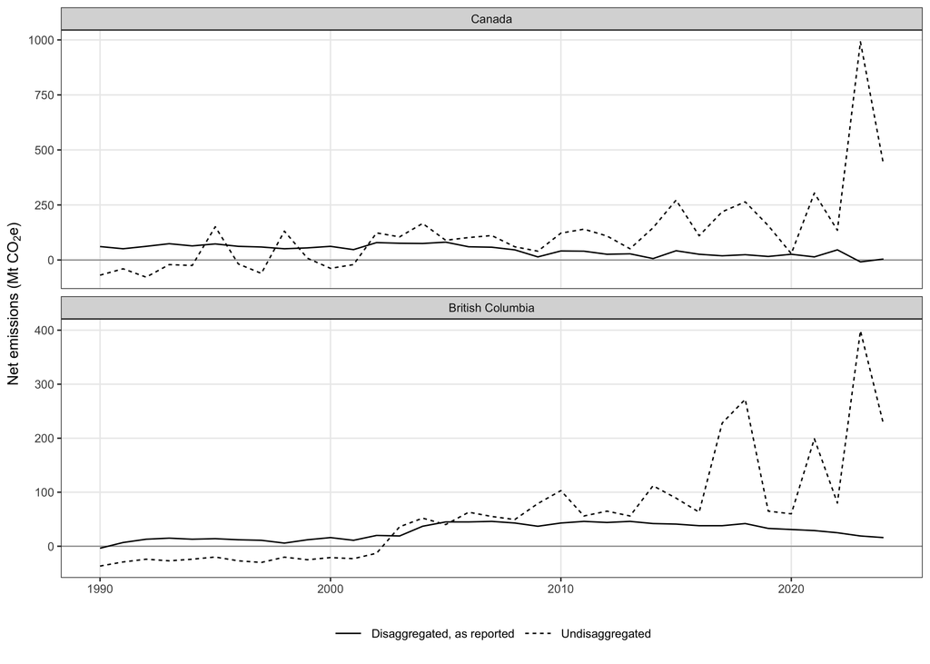

Figure 1: Net emissions of the land use sector for Canada and British Columbia, 1990 to 2024, in the account Canada reports, with natural disturbance separated, and in the undisaggregated account, the reported total plus the natural disturbance component. Positive values are emissions and negative values are removals.

```r
eccc |>
  dplyr::mutate(region = factor(dplyr::if_else(region == "BC", "British Columbia", region), levels = c("Canada", "British Columbia"))) |>
  tidyr::pivot_longer(c(human, net), names_to = "account", values_to = "mt") |>
  dplyr::mutate(account = dplyr::if_else(account == "human", "Disaggregated, as reported", "Undisaggregated")) |>
  ggplot2::ggplot(ggplot2::aes(year, mt, linetype = account)) +
  ggplot2::geom_hline(yintercept = 0, linewidth = 0.3, colour = "grey60") +
  ggplot2::geom_line() +
  ggplot2::facet_wrap(~region, ncol = 1, scales = "free_y") +
  ggplot2::labs(x = NULL, y = expression("Net emissions (Mt CO"[2]*"e)"), linetype = NULL) +
  th +
  ggplot2::theme(legend.position = "bottom")
```

Separating natural disturbance cut the standard deviation of Canada’s annual land use emissions from 190 to 24 Mt CO<sub>2</sub>e over 1990 to 2024, a factor of 7.9 (Figure 1). The account Canada reported averaged 44.6 ± 24.0 Mt CO<sub>2</sub>e a year (95 per cent confidence interval 36.3 to 52.8), against 119.9 ± 190.0 Mt CO<sub>2</sub>e a year (95 per cent confidence interval 54.7 to 185.2) without the separation. The difference, the natural disturbance component, ran from -140 Mt in 1992 to 1,000 Mt in 2023, and in 2023 Canada reported -8.7 Mt where the undisaggregated account showed 991 Mt. British Columbia’s reported account averaged 27.2 ± 14.9 Mt CO<sub>2</sub>e a year (95 per cent confidence interval 22.0 to 32.3) against 60.8 ± 99.4 Mt CO<sub>2</sub>e a year (95 per cent confidence interval 26.6 to 94.9) without the separation, a standard deviation 6.7 times larger, and in 2023 the province reported 19 Mt against 399 Mt.

## 3.2 Fire emissions in Canada

```r
readr::write_csv(forest, "03.outputs/TBL/tbl-canada-forest.csv")
fmt_tbl(forest)
```

Table 2: Carbon dioxide from forest fires in Canada as FAOSTAT computes it at Tier 1, with the burned area it was derived from. The series begins in 2001 because that is the first year of the MODIS burned area input.

| Year | Burned area (ha) | CH4 (kt) | CO2 (kt) |
| --- | --- | --- | --- |
| 2,001 | 19,773.77 | 2.0249 | 1,420.085 |
| 2,002 | 101,943.82 | 9.9021 | 6,944.383 |
| 2,003 | 230,304.01 | 24.4737 | 17,163.481 |
| 2,004 | 167,748.37 | 16.5832 | 11,629.860 |
| 2,005 | 97,542.49 | 9.5089 | 6,668.648 |
| 2,006 | 146,045.61 | 14.3965 | 10,096.295 |
| 2,007 | 67,697.31 | 7.2428 | 5,079.409 |
| 2,008 | 27,018.12 | 2.7528 | 1,930.524 |
| 2,009 | 82,928.65 | 8.6638 | 6,075.961 |
| 2,010 | 176,295.60 | 19.3049 | 13,538.611 |
| 2,011 | 192,658.86 | 18.2590 | 12,805.143 |
| 2,012 | 247,003.14 | 24.1714 | 16,951.493 |
| 2,013 | 252,611.77 | 23.9457 | 16,793.223 |
| 2,014 | 147,474.89 | 15.7320 | 11,032.937 |
| 2,015 | 593,947.85 | 56.8983 | 39,902.996 |
| 2,016 | 213,589.28 | 20.2858 | 14,226.529 |
| 2,017 | 240,883.06 | 26.1074 | 18,309.234 |
| 2,018 | 606,890.34 | 63.5046 | 44,536.078 |
| 2,019 | 296,516.62 | 28.1474 | 19,739.897 |
| 2,020 | 40,890.88 | 4.0396 | 2,832.990 |
| 2,021 | 575,038.62 | 60.5564 | 42,468.496 |
| 2,022 | 172,378.52 | 17.4766 | 12,256.448 |
| 2,023 | 2,749,985.32 | 266.6721 | 187,018.316 |
| 2,024 | 717,855.47 | 70.1121 | 49,169.902 |

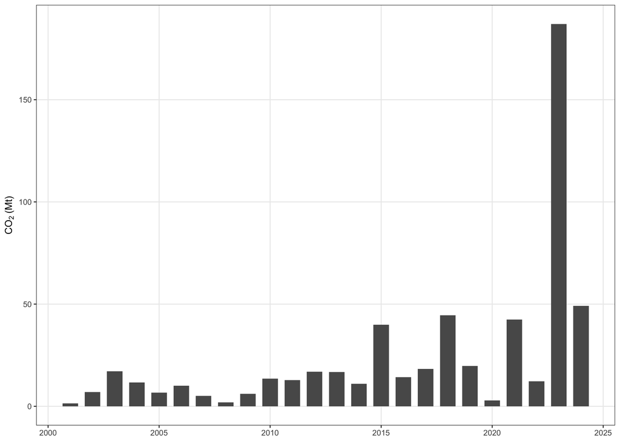

Figure 2: Carbon dioxide from forest fires in Canada, 2001 to 2024, as computed by FAOSTAT at Tier 1 from MODIS burned area.

```r
ggplot2::ggplot(forest, ggplot2::aes(Year, `CO2 (kt)` / 1000)) +
  ggplot2::geom_col(width = 0.7) +
  ggplot2::labs(x = NULL, y = expression(CO[2]~"(Mt)")) +
  th
```

```r
readr::write_csv(gap, "03.outputs/TBL/tbl-source-gap.csv")
fmt_tbl(gap)
```

Table 3: Carbon dioxide from fires in other forest in Canada, as FAOSTAT computes it at Tier 1 and as Canada reported it to the UNFCCC, for the years both are available. FAOSTAT carries the reported series inside the same domain.

| Year | FAO Tier 1 (kt) | UNFCCC (kt) | Ratio |
| --- | --- | --- | --- |
| 2,001 | 1,420.085 | 5,937.187 | 0.2 |
| 2,002 | 6,944.383 | 6,600.562 | 1.1 |
| 2,003 | 17,163.481 | 6,477.020 | 2.6 |
| 2,004 | 11,629.860 | 6,223.502 | 1.9 |
| 2,005 | 6,668.648 | 7,252.098 | 0.9 |
| 2,006 | 10,096.295 | 6,247.804 | 1.6 |
| 2,007 | 5,079.409 | 5,603.096 | 0.9 |
| 2,008 | 1,930.524 | 4,643.541 | 0.4 |
| 2,009 | 6,075.961 | 3,987.953 | 1.5 |
| 2,010 | 13,538.611 | 4,836.967 | 2.8 |
| 2,011 | 12,805.143 | 4,878.594 | 2.6 |
| 2,012 | 16,951.493 | 4,999.909 | 3.4 |
| 2,013 | 16,793.223 | 4,814.442 | 3.5 |
| 2,014 | 11,032.937 | 4,260.117 | 2.6 |
| 2,015 | 39,902.996 | 5,032.216 | 7.9 |
| 2,016 | 14,226.529 | 4,368.008 | 3.3 |
| 2,017 | 18,309.234 | 3,840.632 | 4.8 |
| 2,018 | 44,536.078 | 3,553.743 | 12.5 |
| 2,019 | 19,739.897 | 2,506.846 | 7.9 |
| 2,020 | 2,832.990 | 2,466.193 | 1.1 |

Across the 20 years both sources reported, the FAOSTAT Tier 1 estimate was a median of 2.6 times the value Canada submitted, from 0.2 times in 2001 to 12.5 times in 2018 (Table 3).

## 3.3 FAOSTAT’s coefficients

```r
readr::write_csv(coefficients, "03.outputs/TBL/tbl-coefficients.csv")
fmt_tbl(coefficients)
```

Table 4: Fuel consumption and emission factors FAOSTAT applied to fires in Canada, 2001 to 2024, recovered from its own published values by dividing the biomass burned of each item by its burned area and each emission by the biomass burned, with the rows of Tables 2.4 and 2.5 of the 2006 IPCC Guidelines that the values equal. Carbon dioxide is not reported for the savanna, grassland and shrubland items.

| Item | Burned area (kha a year) | Fuel (t/ha) | Table 2.4 row | CO2 (g/kg) | CH4 (g/kg) | N2O (g/kg) | Table 2.5 row |
| --- | --- | --- | --- | --- | --- | --- | --- |
| Other forest | 340 | 41.2 to 47.6 | All boreal forest to All other temperate forests | 1,613 | 2.3 | 0.21 | Savanna and grassland |
| Closed shrubland | 0 | 26.7 | Shrubland (general) | not reported | 2.3 | 0.21 | Savanna and grassland |
| Grassland | 56 | 4.1 | Grassland, mid or late dry season burns | not reported | 2.3 | 0.21 | Savanna and grassland |
| Open shrubland | 35 | 14.3 | All shrublands | not reported | 2.3 | 0.21 | Savanna and grassland |
| Savanna | 754 | 4.1 | Grassland, mid or late dry season burns | not reported | 2.3 | 0.21 | Savanna and grassland |
| Woody savanna | 1,195 | 3.3 | Savanna woodland, mid or late dry season burns | not reported | 2.3 | 0.21 | Savanna and grassland |

FAOSTAT’s published values for Canada showed which coefficients it had applied (Table 4). Its biomass burned divided by its burned area gave 41.2 to 47.6 tonnes of dry matter per hectare for other forest. That range lay between the 41.0 of Table 2.4 for all boreal forest and the 50.4 for all other temperate forests, as allocation by ecological zone would give (Aalde et al., 2006; Food and Agriculture Organization of the United Nations, 2025). Its emissions divided by its biomass burned gave 1,613 g of carbon dioxide, 2.3 g of methane and 0.21 g of nitrous oxide per kilogram of dry matter burned in forest fires in every year. These were the factors of Table 2.5 for savanna and grassland rather than those for extra tropical forest, 1,569, 4.7 and 0.26, a row the table notes “includes all other forest types” (Aalde et al., 2006). The methane FAOSTAT reported for Canada’s forest fires was therefore 49 per cent of what its cited factors gave, the nitrous oxide 81 per cent and the carbon dioxide 103 per cent. The domain also placed 86 per cent of the area it recorded as burned in Canada over 2001 to 2024, and 79 per cent in 2023, in its savanna, grassland and shrubland items. To these it applied the Table 2.4 values for savanna woodland and grassland burned in the mid or late dry season, 3.3 and 4.1 tonnes per hectare, and it reported no carbon dioxide for them.

## 3.4 Classifying a fire year as natural

```r
readr::write_csv(baselines, "03.outputs/TBL/tbl-baselines.csv")
fmt_tbl(baselines)
```

Table 5: The natural disturbance threshold applied to Canadian forest fire emissions under three baseline lengths. The threshold is the baseline mean plus two standard deviations, and the years listed are those the rule classifies as natural.

| Baseline (years) | Period | Threshold (kt) | Years classified natural |
| --- | --- | --- | --- |
| 13 | 2001-2013 | 20,837 | 2015, 2018, 2021, 2023, 2024 |
| 20 | 2001-2020 | 36,301 | 2015, 2018, 2021, 2023, 2024 |
| 30 |  |  | baseline longer than the series |

The baseline length moved the threshold but not the classification. Lengthening the baseline from 13 to 20 years raised the threshold from 20,837 to 36,301 kilotonnes of carbon dioxide, a rise of 74 per cent, and both lengths classed the same 5 years as natural, 2015, 2018, 2021, 2023, 2024 (Table 5). A 30 year baseline could not be run, because the FAOSTAT series covered only 24 years derived from observations, 2001 to 2024, and the earlier years were filled rather than measured.

## 3.5 Crediting with and without the separation

```r
readr::write_csv(credits, "03.outputs/TBL/tbl-credits.csv")
fmt_tbl(credits)
```

Table 6: Emissions and reductions for Canada’s managed land under the two accounts, 2017 to 2024, on a 2012 to 2016 reference period. The disaggregated account is the human activity component Canada reports; the undisaggregated account is the sum of the human activity and natural disturbance components. A negative reduction is emissions above the crediting level, which the standard treats as a reversal.

| Year | Disaggregated emissions (Mt) | Disaggregated reductions (Mt) | Undisaggregated emissions (Mt) | Undisaggregated reductions (Mt) |
| --- | --- | --- | --- | --- |
| 2,017 | 19.0 | 6.7 | 219.0 | -81.3 |
| 2,018 | 24.0 | 1.7 | 264.0 | -126.3 |
| 2,019 | 16.0 | 9.7 | 156.0 | -18.3 |
| 2,020 | 26.0 | -0.3 | 28.7 | 109.0 |
| 2,021 | 14.0 | 11.7 | 304.0 | -166.3 |
| 2,022 | 46.0 | -20.3 | 135.0 | 2.7 |
| 2,023 | -8.7 | 34.4 | 991.3 | -853.6 |
| 2,024 | 4.3 | 21.4 | 434.3 | -296.6 |

The separation decided whether there was anything to credit. On the account Canada reported, reductions were positive in 6 of the 8 crediting years and summed to 85.6 Mt of carbon dioxide equivalent, with 2 years below the crediting level, 2020 at -0.3 Mt and 2022 at -20.3 Mt. Without the separation, reductions were positive in only 2 years, and the shortfall in 2023 alone reached 853.6 Mt, 10 times every reduction the disaggregated account achieved over the period (Table 6).

Neither deduction applied in that case, because there was nothing to deduct from. The standard’s reversal rule retired buffer credits equal to the lower of the emissions above the crediting level or every credit issued, so an undisaggregated account of this land exhausted its buffer in 2017 and again in each later year that emissions exceeded the level (Architecture for REDD+ Transactions, 2021).

## 3.6 Crediting in British Columbia

```r
readr::write_csv(bc_credits, "03.outputs/TBL/tbl-bc.csv")
fmt_tbl(bc_credits)
```

Table 7: Emissions and reductions for British Columbia under the two accounts, 2017 to 2024, on a 2012 to 2016 reference period. Both components are the provincial figures of the national inventory, and the burned area share is the province’s share of the area burned in Canada.

| Year | Burned area share (%) | Disaggregated emissions (Mt) | Disaggregated reductions (Mt) | Undisaggregated emissions (Mt) | Undisaggregated reductions (Mt) |
| --- | --- | --- | --- | --- | --- |
| 2,017 | 35.9 | 38 | 4.2 | 228 | -151 |
| 2,018 | 60.5 | 42 | 0.2 | 272 | -195 |
| 2,019 | 1.5 | 33 | 9.2 | 65 | 12 |
| 2,020 | 6.6 | 31 | 11.2 | 60 | 17 |
| 2,021 | 21.1 | 29 | 13.2 | 199 | -122 |
| 2,022 | 9.0 | 25 | 17.2 | 80 | -3 |
| 2,023 | 22.2 | 19 | 23.2 | 399 | -322 |
| 2,024 | 20.8 | 16 | 26.2 | 226 | -149 |

British Columbia followed the national pattern more sharply. The province had 60.5 per cent of the area burned in Canada in 2018 and 22.2 per cent in 2023. On the disaggregated account its reductions were positive in 8 of the 8 crediting years, summing to 104.6 Mt of carbon dioxide equivalent, and without the separation they were positive in 2 years, with 2023 falling 322 Mt below the crediting level (Table 7).

## 3.7 The uncertainty of each account

```r
readr::write_csv(uncertainty, "03.outputs/TBL/tbl-uncertainty.csv")
fmt_tbl(uncertainty)
```

Table 8: Reductions and their uncertainty for Canada under the two accounts, from 10,000 Monte Carlo draws using the annual flux uncertainty published for Canada’s forest carbon model. The interval is the 90 per cent interval the standard requires, its half width expressed against the mean reduction of the same draws, and the deduction is what the standard’s adjustment factor takes from it. A percentage is printed only where the mean reduction is positive, since a percentage of a shortfall carries no meaning, and the undisaggregated deduction is therefore not reported.

| Year | Disaggregated reductions (Mt) | Disaggregated interval (% of mean) | Disaggregated deduction (%) | Undisaggregated reductions (Mt) | Undisaggregated interval (% of mean) |
| --- | --- | --- | --- | --- | --- |
| 2,017 | 6.7 | 821 | 261.6 | -80.8 |  |
| 2,018 | 1.5 | 3,692 | 1,176.9 | -126.5 |  |
| 2,019 | 9.7 | 574 | 182.9 | -18.5 |  |
| 2,020 | -0.7 |  |  | 109.4 | 52 |
| 2,021 | 12.0 | 458 | 146.0 | -165.7 |  |
| 2,022 | -20.2 |  |  | 2.6 | 2,126 |
| 2,023 | 34.4 | 163 | 51.8 | -853.8 |  |
| 2,024 | 21.4 | 264 | 84.2 | -296.9 |  |

Canada’s own uncertainty analysis of its model reported a 95 per cent interval 118 Mt of carbon dioxide equivalent wide around a median of -2.9 Mt, and stated that this interval “cannot be meaningfully expressed in percentage terms because its range of possible values contains zero” (Metsaranta et al., 2017). In the crediting arithmetic the interval was wider than the reductions it qualified. Across the 6 crediting years with a positive mean reduction, the interval of the disaggregated account ran from 163 to 3,692 per cent of its mean reduction, and the implied uncertainty deduction from 51.8 to 1,176.9 per cent (Table 8). The separation restored the sign of the account but left the credit uncertain by more than its own size.

## 3.8 What survives the deductions

```r
readr::write_csv(deductions, "03.outputs/TBL/tbl-kept.csv")
fmt_tbl(deductions)
```

Table 9: The share of gross reductions and removals a jurisdiction keeps under the standard, by the reported uncertainty. The uncertainty deduction follows Equation 11 and the buffer follows Table 2 of the standard. The last column is the worst case in the five years after a reversal, when the buffer rises by five percentage points.

| Uncertainty, 90% interval half width (%) | Uncertainty deduction (%) | Kept, 25% buffer (%) | Kept, 5% buffer (%) | Kept, 30% buffer after a reversal (%) |
| --- | --- | --- | --- | --- |
| 10 | 3.2 | 71.8 | 91.8 | 66.8 |
| 20 | 6.4 | 68.6 | 88.6 | 63.6 |
| 30 | 9.6 | 65.4 | 85.4 | 60.4 |
| 50 | 15.9 | 59.1 | 79.1 | 54.1 |
| 75 | 23.9 | 51.1 | 71.1 | 46.1 |
| 100 | 31.9 | 43.1 | 63.1 | 38.1 |
| 150 | 47.8 | 27.2 | 47.2 | 22.2 |
| 200 | 63.8 | 11.2 | 31.2 | 6.2 |

The two deductions were linear in the reported uncertainty, so the uncertainty at which a jurisdiction kept nothing could be solved directly. On the default buffer it was 235 per cent, with all three mitigating factors and the smallest buffer 298 per cent, and in the five years after a reversal 220 per cent. At an uncertainty of 100 per cent a jurisdiction kept 43.1 per cent of its gross reductions and removals on the default buffer, and at 150 per cent it kept 27.2 per cent (Table 9). Uncertainty of that size was not hypothetical, since the worked example of the uncertainty chapter printed ±150 per cent for one land category (Paciornik et al., 2019).

## 3.9 Fires in organic soils

```r
readr::write_csv(canada, "03.outputs/TBL/tbl-canada-peat.csv")
fmt_tbl(canada)
```

Table 10: Burned area and emissions from fires in organic soils in Canada, as FAO computed them and then set them to zero in the published Emissions from Fires domain. Values for 1990 to 1995 are the average of the reconstructed series rather than observations, which is why they do not vary.

| Year | CH4 (kt) | Burned area (ha) | CO2 (kt) |
| --- | --- | --- | --- |
| 1,990 | 257.61615 | 356,482.42 | 32,682.923 |
| 1,991 | 257.61615 | 356,482.42 | 32,682.923 |
| 1,992 | 257.61615 | 356,482.42 | 32,682.923 |
| 1,993 | 257.61615 | 356,482.42 | 32,682.923 |
| 1,994 | 257.61615 | 356,482.42 | 32,682.923 |
| 1,995 | 257.61615 | 356,482.42 | 32,682.923 |
| 1,996 | 315.23052 | 229,625.96 | 25,809.499 |
| 1,997 | 170.40705 | 124,131.01 | 13,952.077 |
| 1,998 | 1,015.27769 | 739,567.08 | 83,125.860 |
| 1,999 | 439.44356 | 320,107.49 | 35,979.441 |
| 2,000 | 161.68439 | 117,777.09 | 13,237.909 |
| 2,001 | 30.23739 | 50,904.70 | 4,458.335 |
| 2,002 | 287.54083 | 484,075.47 | 42,396.298 |
| 2,003 | 306.03608 | 515,212.26 | 45,123.320 |
| 2,004 | 173.45735 | 292,015.74 | 25,575.323 |
| 2,005 | 165.94913 | 279,375.64 | 24,468.277 |
| 2,006 | 219.41289 | 369,381.97 | 32,351.212 |
| 2,007 | 154.83941 | 260,672.40 | 22,830.210 |
| 2,008 | 189.87328 | 319,651.99 | 27,995.761 |
| 2,009 | 38.33478 | 64,536.66 | 5,652.250 |
| 2,010 | 281.27927 | 473,534.13 | 41,473.066 |
| 2,011 | 126.49251 | 212,950.35 | 18,650.618 |
| 2,012 | 256.69793 | 432,151.40 | 37,848.683 |
| 2,013 | 457.77889 | 770,671.53 | 67,496.954 |
| 2,014 | 314.12631 | 528,832.17 | 46,316.179 |
| 2,015 | 459.60190 | 773,740.57 | 67,765.747 |
| 2,016 | 205.94202 | 346,703.73 | 30,365.006 |
| 2,017 | 251.91707 | 424,102.81 | 37,143.773 |
| 2,018 | 81.74237 | 137,613.42 | 12,052.459 |
| 2,019 | 174.33455 | 293,492.50 | 25,704.660 |
| 2,020 | 11.04954 | 18,601.91 | 1,629.193 |
| 2,021 | 409.33311 | 689,112.98 | 60,353.893 |

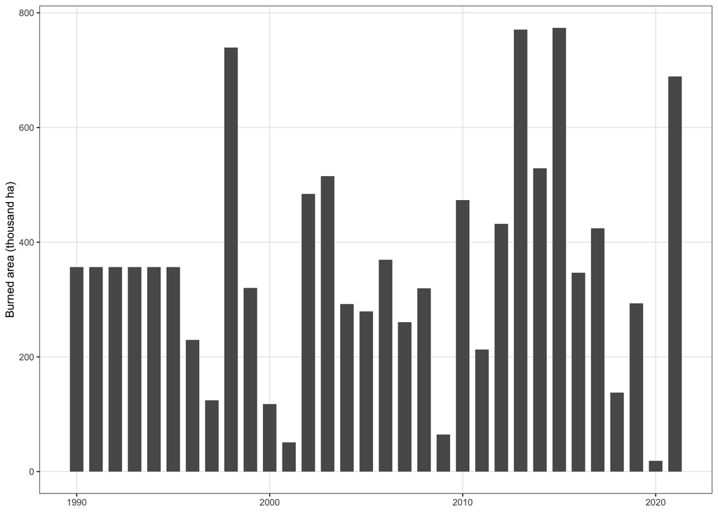

Figure 3: Burned area of fires in organic soils in Canada, 1990 to 2021, from the FAO table that the published domain replaces with zeros. The flat section to 1995 is the filled part of the series and the rest is derived from satellite observations.

```r
ggplot2::ggplot(canada, ggplot2::aes(Year, `Burned area (ha)` / 1000)) +
  ggplot2::geom_col(width = 0.7) +
  ggplot2::labs(x = NULL, y = "Burned area (thousand ha)") +
  th
```

Over the 21 years of the satellite record, 2001 to 2021, fires in organic soils in Canada burned a mean of 368,444 hectares a year. They released 32,269 kilotonnes of carbon dioxide and 219 kilotonnes of methane a year, none of which appeared in the FAOSTAT domain a government downloaded. The largest year was 2015, at 773,741 hectares and 67,766 kilotonnes of carbon dioxide, and the smallest was 2020, at 18,602 hectares.

The six years from 1990 to 1995 repeated one value, 356,482 hectares, which was the mean of every later year to the last digit the table printed, 356,482.42 hectares for 1996 to 2021 against 356,482.42. The filled years were therefore the average of the whole remaining series rather than of the window the methodological note described, so any mean over the full series returned that value whatever the observations did.

# 4 Discussion

On the components of Canada’s 2026 inventory, separating natural disturbance decided whether an account existed to credit in 2017 to 2024, but it did not make that account precise. The managed land of the country reported reductions in 6 of the 8 years, totalling 85.6 Mt of carbon dioxide equivalent, while the same land without the separation reported them in 2 years and fell 853.6 Mt short of its crediting level in 2023 alone. British Columbia, with 22.2 per cent of the area burned in Canada that year, reversed in the same way, reporting 104.6 Mt separated against a shortfall of 322 Mt. The separation was therefore the condition on which a jurisdictional credit existed rather than an adjustment to a reported number. Earlier work found the same dependence in reporting, where natural disturbance was among the reasons Canada did not elect forest management under the Kyoto Protocol (Kurz et al., 2008) and a revised harvest record moved the reported human sink by 113 Mt CO<sub>2</sub>e in 1990 (Kurz et al., 2024). The treatment of wildfire as natural also separated a forestry source of 90.8 Mt CO<sub>2</sub>e a year from a reported sink of 4.7 Mt (Bysouth et al., 2024). In each case the partition rather than the forest moved the balance, and a standard that took the reported balance as its input passed the partition straight into the credit.

The rest of this Discussion took in turn the uncertainty of a net near zero, the record and regrowth period behind the separation and the fire emission method, then the buffers of the standards and the changes that would close these gaps.

The separated account kept part of its reductions in only 1 of the 6 years with a positive reduction, for an arithmetic rather than an ecological reason. An account whose emissions and removals nearly cancelled reported a percentage uncertainty far larger than either side of it, the case Paciornik et al. (2019) warned against interpreting. Canada’s own inventory met the same limit in 2024, printing the 95 per cent interval of the carbon dioxide of Forest Land, a net of −1.9 Mt within −63 to 19 Mt, as 3,100 and −1,100 per cent (Environment and Climate Change Canada, 2026). Applied to the crediting equations, the published interval gave uncertainty deductions of 51.8 to 1,176.9 per cent, larger than the reduction in 4 of the 6 years with a positive reduction and smaller only in 2023 and 2024. The separation thus moved the reported quantity away from zero in the years the fires dominated and left it near zero in the others. In 2023 the account kept 18.2 per cent of its reduction, after the uncertainty deduction and a buffer that the shortfall of 2020 had raised to 30 per cent. Regional budgets elsewhere were also near zero within their uncertainty, and in California the data could not establish whether the land was a source or a sink (Di Vittorio et al., 2021; Haverd et al., 2013; Rosan et al., 2023). The standards differed in what such an interval cost. The adjustment factor of ART TREES rose with the interval without limit (Architecture for REDD+ Transactions, 2021), whereas the Forest Carbon Partnership Facility capped its uncertainty set-aside at 15 per cent (Forest Carbon Partnership Facility, 2024), under which a positive reduction kept at least 51 per cent of itself after both set-asides.

The length of the record mattered less to the classification than to the threshold. Lengthening the baseline from 13 to 20 years raised the threshold by 74 per cent and marked the same five years, and a 30 year baseline could not be tested because the satellite record covered only 24 years. The fire regime literature found estimates sensitive to the record in the same way, with Weibull parameters that changed between 22 and 31 years of data (Oliveira et al., 2011) and fire cycle estimates degraded by short-term variation in fire activity (Cyr et al., 2016). Fire cycles in Canada ran from 50 to 769 years (Arsenault et al., 2016; Johnson & Larsen, 1991), so a baseline of 13 to 30 years sampled a small part of one cycle. Fire history therefore turned to centuries of tree rings and millennia of charcoal wherever recent fires were too few (Gavin et al., 2007). Of the three crediting documents read for this study, only Verra’s tool set a record length, 100 years with no fewer than 20 (Verra, 2024). Canada applied no baseline at all, reconstructing instead the cause of every stand for 1889 to 1989 and keeping each burned area in the natural category for the 60 to 100 years it took to regrow to a harvestable age (Kurz et al., 2024). Australia tested fire seasons against a 13 year mean (Bowman et al., 2023), and the European example in the guidance used the 20 years before the base year and assumed 20 years of regrowth (Ogle et al., 2019). Three implementations thus used three temporal designs under guidance that specified none. The regrowth half of the account also contained the error of the model, which underestimated the net biomass gain of undisturbed boreal stands by 10 per cent over 71 years (Bernier et al., 2010). That regrowth was what returned to the human account when a burned stand crossed the age threshold.

The fire emissions inside both accounts came from one method. Canada’s fire matrices assumed high severity throughout, and a severity-based sub-model gave regional emissions typically 10 to 25 per cent lower (Thompson et al., 2026). Both accounts shared that difference, and the account without the separation took nearly all of it, because Canada placed every wildfire in the natural component (Environment and Climate Change Canada, 2026). FAOSTAT’s Tier 1 estimate ran a median of 2.6 times the value Canada submitted, which put the choice of source on the same scale as the choice of method. Part of that gap lay in coefficients the methodological note did not state. FAOSTAT applied the savanna and grassland emission factors to Canada’s forest fires, which put its methane at 49 per cent of what its cited method gave. It also placed 86 per cent of the area it recorded as burned in savanna, grassland and shrubland items, which it burned at the fuel values of tropical savanna and reported without carbon dioxide. Most of the area FAOSTAT recorded as burned in Canada therefore contributed no carbon dioxide to the estimate a government would check its inventory against. Differences of this size were common among fire estimates (Kukavskaya et al., 2013; Vallet et al., 2025), and FAOSTAT’s estimate of the global land sector differed in sign from what countries reported (Grassi et al., 2022). The same database set Canada’s organic soil fire emissions to zero while computing them at a mean of 32,269 kilotonnes of carbon dioxide a year over the satellite record (Food and Agriculture Organization of the United Nations, 2025).

The buffers withheld against reversal did not follow the fire regime of the land they covered. ART TREES applied 25 per cent to every jurisdiction unless three mitigating factors were met (Architecture for REDD+ Transactions, 2021), and the Forest Carbon Partnership Facility added 0 to 5 percentage points for exposure to natural disturbance (Forest Carbon Partnership Facility, 2024). Only Verra’s tool scored the history of events in the area itself, and then for projects rather than jurisdictions (Verra, 2024). Fire cycles in Canada differed more than tenfold between regions (Arsenault et al., 2016; Bélisle et al., 2011; Johnson & Larsen, 1991), and North American conifer forests were among those with the highest reversal risk (Wu et al., 2026). British Columbia, with 60.5 per cent of the area burned in Canada in 2018 and 22.2 per cent in 2023, fell 322 Mt short on its own unseparated account. These were grounds for buffer contributions set from regional fire regime statistics, as the contributions prepared for the carbon removals regulation of the European Union were set from modelled regional loss to disturbance (Marinelli et al., 2026).

Crediting standards inherited the silence of the guidance, because the REDD+ Environmental Excellence Standard allowed natural disturbance to be excluded on the authority of the guidance without saying how far back the record must reach (Architecture for REDD+ Transactions, 2025; Ogle et al., 2019). Two jurisdictions applying the same clause to the same fire record could therefore report different natural shares, depending on how far back their labelling reached and how long their regrowth ran. Four changes would close the gap, the first being to specify the record length behind any natural disturbance test and the second to state the regrowth period over which later removals were disaggregated. The third was to take the uncertainty deduction from gross emissions and gross removals rather than from a net near zero, and the fourth to set buffer contributions from the regional fire regime.

Two limits qualified these results, the first being that the uncertainty analysis applied one published interval to every annual flux, which assumed the model was as certain of a quiet year as of a megafire year. The second was that both accounts used Canada’s figures as reported, so the study compared two sums of one model’s output, with fire matrices that assumed high severity (Thompson et al., 2026), and FAOSTAT was its only independent estimate.

# 5 Conclusions

Run through the crediting level, uncertainty deduction and buffer of the REDD+ Environmental Excellence Standard for 2017 to 2024, Canada’s managed land achieved 85.6 Mt of carbon dioxide equivalent with natural disturbance separated and fell 853.6 Mt short in 2023 alone without it. A jurisdiction in a megafire regime could therefore report a creditable balance only by excluding the fires, under guidance that set no record length for doing so. The separated account remained uncertain by more than its own size, with uncertainty deductions of 51.8 to 1,176.9 per cent, and kept part of its reductions only in 2023, 18.2 per cent of them. FAOSTAT’s fire estimate for Canada, the independent check a government reached for, rested on savanna emission factors and savanna fuel values that its method did not state. Standards that relied on the separation needed a stated record length, a stated regrowth period, an uncertainty deduction on gross fluxes and buffers set from regional fire regimes. The code and data behind every number here were published so that a government could repeat the comparison.

# Word count

# References

Aalde, H., Gonzalez, P., Gytarsky, M., Krug, T., Kurz, W. A., Lasco, R. D., Martino, D. L., McConkey, B. G., Ogle, S., Paustian, K., Raison, J., Ravindranath, N. H., Schoene, D., Smith, P., Somogyi, Z., Amstel, A. van, & Verchot, L. (2006). Chapter 2: Generic methodologies applicable to multiple land-use categories. In H. S. Eggleston, L. Buendia, K. Miwa, T. Ngara, & K. Tanabe (Eds.), *2006 IPCC guidelines for national greenhouse gas inventories, volume 4: Agriculture, forestry and other land use*. Institute for Global Environmental Strategies.

Architecture for REDD+ Transactions. (2021). *The REDD+ environmental excellence standard (TREES), version 2.0*. Architecture for REDD+ Transactions.

Architecture for REDD+ Transactions. (2025). *The REDD+ environmental excellence standard (TREES), version 3.0, public comment draft*. Architecture for REDD+ Transactions.

Arksey, H., & O’Malley, L. (2005). Scoping studies: Towards a methodological framework. *International Journal of Social Research Methodology*, *8*(1), 19–32. https://doi.org/10.1080/1364557032000119616

Arsenault, A., LeBlanc, R., Earle, E., Brooks, D., Clarke, B., Lavigne, D., & Royer, L. (2016). Unravelling the past to manage Newfoundland’s forests for the future. *The Forestry Chronicle*, *92*(04), 487–502. https://doi.org/10.5558/tfc2016-085

Bélisle, A., Gauthier, S., Cyr, D., Bergeron, Y., & Morin, H. (2011). Fire regime and old-growth boreal forests in central Quebec, Canada: an ecosystem management perspective. *Silva Fennica*, *45*(5). https://doi.org/10.14214/sf.77

Bernier, P. Y., Guindon, L., Kurz, W. A., & Stinson, G. (2010). Reconstructing and modelling 71 years of forest growth in a Canadian boreal landscape: a test of the CBM-CFS3 carbon accounting model. *Canadian Journal of Forest Research*, *40*(1), 109–118. https://doi.org/10.1139/x09-177

Bowman, D. M. J. S., Williamson, G. J., Ndalila, M., Roxburgh, S. H., Suitor, S., & Keenan, R. J. (2023). Wildfire national carbon accounting: How natural and anthropogenic landscape fires emissions are treated in the 2020 Australian government greenhouse gas accounts report to the UNFCCC. *Carbon Balance and Management*, *18*(1), 14. https://doi.org/10.1186/s13021-023-00231-3

Bysouth, D., Boan, J. J., Malcolm, J. R., & Taylor, A. R. (2024). High emissions or carbon neutral? Inclusion of “anthropogenic” forest sinks leads to underreporting of forestry emissions. *Frontiers in Forests and Global Change*, *6*. https://doi.org/10.3389/ffgc.2023.1297301

Canadell, J. G., Kirschbaum, M. U. F., Kurz, W. A., Sanz, M.-J., Schlamadinger, B., & Yamagata, Y. (2007). Factoring out natural and indirect human effects on terrestrial carbon sources and sinks. *Environmental Science &Amp; Policy*, *10*(4), 370–384. https://doi.org/10.1016/j.envsci.2007.01.009

Cyr, D., Gauthier, S., Boulanger, Y., & Bergeron, Y. (2016). Quantifying Fire Cycle from Dendroecological Records Using Survival Analyses. *Forests*, *7*(7), 131. https://doi.org/10.3390/f7070131

Di Vittorio, A. V., Simmonds, M. B., & Nico, P. (2021). Quantifying the effects of multiple land management practices, land cover change, and wildfire on the California landscape carbon budget with an empirical model. *PLOS ONE*, *16*(5), e0251346. https://doi.org/10.1371/journal.pone.0251346

Environment and Climate Change Canada. (2026). *National inventory report 1990–2024: Greenhouse gas sources and sinks in Canada*. Environment and Climate Change Canada.

Finney, M. (1995). The Missing Tail and Other Considerations for the Use of Fire History Models. *International Journal of Wildland Fire*, *5*(4), 197–202. https://doi.org/10.1071/wf9950197

Food and Agriculture Organization of the United Nations. (2025). *FAOSTAT domain emissions from fires. Methodological note, release October 2025*. Food and Agriculture Organization of the United Nations. https://www.fao.org/faostat/en/#data/GI

Forest Carbon Partnership Facility. (2024). *Buffer guidelines, version 4.2*. Forest Carbon Partnership Facility Carbon Fund.

Gavin, D. G., Hallett, D. J., Hu, F. S., Lertzman, K. P., Prichard, S. J., Brown, K. J., Lynch, J. A., Bartlein, P., & Peterson, D. L. (2007). Forest fire and climate change in western North America: insights from sediment charcoal records. *Frontiers in Ecology and the Environment*, *5*(9), 499–506. https://doi.org/10.1890/060161

Grassi, G., Conchedda, G., Federici, S., Abad Viñas, R., Korosuo, A., Melo, J., Rossi, S., Sandker, M., Somogyi, Z., Vizzarri, M., & Tubiello, F. N. (2022). Carbon fluxes from land 2000–2020: bringing clarity to countries’ reporting. *Earth System Science Data*, *14*(10), 4643–4666. https://doi.org/10.5194/essd-14-4643-2022

Grassi, G., Pilli, R., House, J., Federici, S., & Kurz, W. A. (2018). Science-based approach for credible accounting of mitigation in managed forests. *Carbon Balance and Management*, *13*(1). https://doi.org/10.1186/s13021-018-0096-2

Haverd, V., Raupach, M. R., Briggs, P. R., Davis, S. J., Law, R. M., Meyer, C. P., Peters, G. P., Pickett-Heaps, C., & Sherman, B. (2013). The Australian terrestrial carbon budget. *Biogeosciences*, *10*(2), 851–869. https://doi.org/10.5194/bg-10-851-2013

Johnson, E. A., & Larsen, C. P. S. (1991). Climatically Induced Change in Fire Frequency in the Southern Canadian Rockies. *Ecology*, *72*(1), 194–201. https://doi.org/10.2307/1938914

Johnson, E. A., & Wagner, C. E. V. (1985). The theory and use of two fire history models. *Canadian Journal of Forest Research*, *15*(1), 214–220. https://doi.org/10.1139/x85-039

Krug, J. H. A. (2018). Accounting of GHG emissions and removals from forest management: a long road from Kyoto to Paris. *Carbon Balance and Management*, *13*(1). https://doi.org/10.1186/s13021-017-0089-6

Kukavskaya, E. A., Soja, A. J., Petkov, A. P., Ponomarev, E. I., Ivanova, G. A., & Conard, S. G. (2013). Fire emissions estimates in Siberia: evaluation of uncertainties in area burned, land cover, and fuel consumption. *Canadian Journal of Forest Research*, *43*(5), 493–506. https://doi.org/10.1139/cjfr-2012-0367

Kurz, W. A., Hayne, S., Fellows, M., MacDonald, J. D., Metsaranta, J. M., Hafer, M., & Blain, D. (2018). Quantifying the impacts of human activities on reported greenhouse gas emissions and removals in Canada’s managed forest: conceptual framework and implementation. *Canadian Journal of Forest Research*, *48*(10), 1227–1240. https://doi.org/10.1139/cjfr-2018-0176

Kurz, W. A., Hudson, B., Neilson, E. T., Fellows, M., Hafer, M., & MacDonald, J. D. (2024). Revised historic harvest data improve estimates of the impacts of human activities on reported greenhouse gas emissions and removals in Canada’s managed forest. *Canadian Journal of Forest Research*, *54*(11), 1376–1389. https://doi.org/10.1139/cjfr-2024-0055

Kurz, W. A., Stinson, G., Rampley, G. J., Dymond, C. C., & Neilson, E. T. (2008). Risk of natural disturbances makes future contribution of Canada’s forests to the global carbon cycle highly uncertain. *Proceedings of the National Academy of Sciences*, *105*(5), 1551–1555. https://doi.org/10.1073/pnas.0708133105

Levac, D., Colquhoun, H., & O’Brien, K. K. (2010). Scoping studies: Advancing the methodology. *Implementation Science*, *5*(1). https://doi.org/10.1186/1748-5908-5-69

Linscheid, N., Mayer, L., Aquino, C., Balzarolo, M., Chiriacò, M. V., Juillard, M., Brandt, M., Chuvieco, E., Ciais, P., Feng, M., Fensholt, R., Kattenborn, T., Khairoun, A., Kowalski, K., Liu, S., Maack, J., Mosig, C., Regnier, P., Senf, C., … Bastos, A. (2026). *EU forest carbon sink decline as seen by Earth observation and national inventories*. Copernicus GmbH. https://doi.org/10.5194/egusphere-2026-6189

Lutz, J. A., Key, C. H., Kolden, C. A., Kane, J. T., & van Wagtendonk, J. W. (2011). Fire Frequency, Area Burned, and Severity: A Quantitative Approach to Defining a Normal Fire Year. *Fire Ecology*, *7*(2), 51–65. https://doi.org/10.4996/fireecology.0702051

Marinelli, D., Pickering, M., Piccardo, M., Ceccherini, G., Cescatti, A., & Migliavacca, M. (2026). *Risk assessment and buffer pool for afforestation projects under the EU Carbon Removals and Carbon Farming regulation* [Dataset]. Zenodo. https://doi.org/10.5281/ZENODO.18803845

Metsaranta, J. M., Kurz, W. A., Neilson, E. T., & Stinson, G. (2010). Implications of future disturbance regimes on the carbon balance of Canada’s managed forest (2010–2100). *Tellus B: Chemical and Physical Meteorology*, *62*(5), 719. https://doi.org/10.1111/j.1600-0889.2010.00487.x

Metsaranta, J. M., Shaw, C. H., Kurz, W. A., Boisvenue, C., & Morken, S. (2017). Uncertainty of inventory-based estimates of the carbon dynamics of Canada’s managed forest (1990–2014). *Canadian Journal of Forest Research*, *47*(8), 1082–1094. https://doi.org/10.1139/cjfr-2017-0088

Nyawira, S. S., Herold, M., Mulatu, K. A., Roman-Cuesta, R. M., Houghton, R. A., Grassi, G., Pongratz, J., Gasser, T., & Verchot, L. (2024). Pantropical CO2 emissions and removals for the AFOLU sector in the period 1990–2018. *Mitigation and Adaptation Strategies for Global Change*, *29*(2). https://doi.org/10.1007/s11027-023-10096-z

Ogle, S. M., Kurz, W. A., Green, C., Brandon, A., Baldock, J., Domke, G., Herold, M., Bernoux, M., et al. (2019). Chapter 2: Generic methodologies applicable to multiple land-use categories. In *2019 refinement to the 2006 IPCC guidelines for national greenhouse gas inventories, volume 4: Agriculture, forestry and other land use*. Intergovernmental Panel on Climate Change.

Oliveira, S. L. J., Pereira, J. M. C., & Carreiras, J. M. B. (2011). Fire frequency analysis in Portugal (1975–2005), using Landsat-based burnt area maps. *International Journal of Wildland Fire*, *21*(1), 48–60. https://doi.org/10.1071/wf10131

Paciornik, N., Gillenwater, M., De Lauretis, R., Romano, D., Monni, S., & Ogle, S. M. (2019). Chapter 3: uncertainties. In E. Calvo Buendia, K. Tanabe, A. Kranjc, J. Baasansuren, M. Fukuda, S. Ngarize, A. Osako, Y. Pyrozhenko, P. Shermanau, & S. Federici (Eds.), *2019 refinement to the 2006 IPCC guidelines for national greenhouse gas inventories, volume 1: General guidance and reporting*. Intergovernmental Panel on Climate Change.

Peters, M. D. J., Marnie, C., Tricco, A. C., Pollock, D., Munn, Z., Alexander, L., McInerney, P., Godfrey, C. M., & Khalil, H. (2020). Updated methodological guidance for the conduct of scoping reviews. *JBI Evidence Synthesis*, *18*(10), 2119–2126. https://doi.org/10.11124/JBIES-20-00167

Petrescu, A. M. R., Abad-Viñas, R., Janssens-Maenhout, G., Blujdea, V. N. B., & Grassi, G. (2012). Global estimates of carbon stock changes in living forest biomass: EDGARv4.3 – time series from 1990 to 2010. *Biogeosciences*, *9*(8), 3437–3447. https://doi.org/10.5194/bg-9-3437-2012

Pilli, R., Grassi, G., Kurz, W. A., Viñas, R. A., & Guerrero, N. H. (2016). Modelling forest carbon stock changes as affected by harvest and natural disturbances. I. Comparison with countries’ estimates for forest management. *Carbon Balance and Management*, *11*(1). https://doi.org/10.1186/s13021-016-0047-8

Poulter, B., Murray-Tortorola, G., Hayes, D., Ciais, P., Bastos, A., & Canadell, P. (2026). *The North American Greenhouse Gas Budget: Emissions, Removals, and Integration for CO2, CH4, and N2O (2010–2019)*. Copernicus GmbH. https://doi.org/10.5194/egusphere-egu26-178

Ritter, F., Ciais, P., Senf, C., Santoro, M., Xu, Y., Pelissier-Tanon, A., Schwartz, M., Fayad, I., Carvalhais, N., Brandt, M., Fensholt, R., Besnard, S., & Avitabile, V. (2025). *Alarming decline in the carbon sink of European forests driven by disturbances*. Springer Science and Business Media LLC. https://doi.org/10.21203/rs.3.rs-3671432/v1

Rosan, T. M., Sitch, S., O’Sullivan, M., Wilson, C., Basso, L. S., Fawcett, D., Heinrich, V. A., Souza, J. G., von Randow, C., Mercado, L. M., Gloor, E., Gatti, L., Friedlingstein, P., Wiltshire, A., Pongratz, J., Schwingshackl, C., & Aragão, L. E. O. C. (2023). *The contemporary Amazon Forest carbon budget*. Copernicus GmbH. https://doi.org/10.5194/egusphere-egu23-3228

Thompson, D. K., Whitman, E., Hafer, M., Hararuk, O., Hanes, C., Manvailer Goncalves, V., & Hudson, B. (2026). Incorporating observed fire severity in refined emissions estimates for boreal and temperate forest fires in the carbon budget model CBM-CFS3 v1.2. *Geoscientific Model Development*, *19*(9), 3617–3642. https://doi.org/10.5194/gmd-19-3617-2026

Tricco, A. C., Lillie, E., Zarin, W., O’Brien, K. K., Colquhoun, H., Levac, D., Moher, D., Peters, M. D. J., Horsley, T., Weeks, L., Hempel, S., Akl, E. A., Chang, C., McGowan, J., Stewart, L., Hartling, L., Aldcroft, A., Wilson, M. G., Garritty, C., … Straus, S. E. (2018). PRISMA extension for scoping reviews (PRISMA-ScR): Checklist and explanation. *Annals of Internal Medicine*, *169*(7), 467–473. https://doi.org/10.7326/M18-0850

Vallet, L., Abdallah, C., Lauvaux, T., Joly, L., Ramonet, M., Ciais, P., Lopez, M., Xueref-Remy, I., & Mouillot, F. (2025). Soil smoldering in temperate forests: a neglected contributor to fire carbon emissions revealed by atmospheric mixing ratios. *Biogeosciences*, *22*(1), 213–242. https://doi.org/10.5194/bg-22-213-2025

Verra. (2024). *AFOLU non-permanence risk tool, version 4.2*. Verra.

Wagner, C. E. V. (1978). Age-class distribution and the forest fire cycle. *Canadian Journal of Forest Research*, *8*(2), 220–227. https://doi.org/10.1139/x78-034

Woodall, C. W., Coulston, J. W., Domke, G. M., Walters, B. F., Wear, D. N., Smith, J. E., Andersen, H.-E., Clough, B. J., Cohen, W. B., Griffith, D. M., Hagen, S. C., Hanou, I. S., Nichols, M. C., Perry, C. H. (Hobie)., Russell, M. B., Westfall, J., & Wilson, B. T. (Ty). (2015). *The U.S. forest carbon accounting framework: stocks and stock change, 1990-2016*. U.S. Department of Agriculture, Forest Service, Northern Research Station. https://doi.org/10.2737/nrs-gtr-154

Wu, C., Goulden, M. L., Randerson, J. T., Trugman, A. T., Wang, J. A., Yang, L., Acil, N., Cook-Patton, S. C., Cullenward, D., Davis, S. J., Williams, C. A., & Anderegg, W. R. L. (2026). *A global analysis of climate-driven reversal risks in forests*. openRxiv. https://doi.org/10.64898/2026.06.19.733404